# 16-Pandas-Batch-405-406-Part2

## Pandas (continuation)

```python
from IPython.core.interactiveshell import InteractiveShell
InteractiveShell.ast_node_interactivity = 'all'

# IMPORT PANDAS
import pandas as pd

import numpy as np
import os
import warnings
warnings.filterwarnings("ignore")
```

## Merge Operations in Pandas

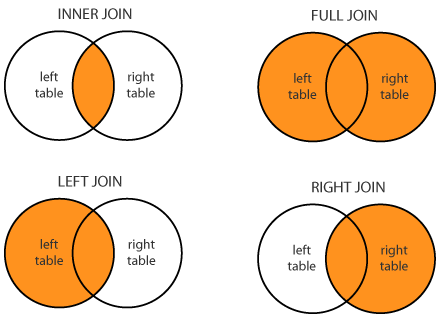

### **INNER JOIN (Intersection)**

- **Set Theory:** $A \cap B$
- This means elements common to both sets.
- **Venn Diagram:** Only the overlapping (middle) part is highlighted.
- **SQL Meaning:** Returns rows where there is a match in both the left and right table.

### 2. **FULL JOIN (Union)**

- **Set Theory:** $A \cup B$
- This means all elements from both sets, with overlap included once.
- **Venn Diagram:** Both circles completely highlighted.
- **SQL Meaning:** Returns all rows when there is a match in **either** left or right table. Missing values are filled with NULLs.

### 3. **LEFT JOIN (Left Outer Join)**

- **Set Theory:** $A \cup (A \cap B)$ but keeping everything from A.
- Simply put: **all elements of A plus the intersection.**
- **Venn Diagram:** Entire left circle is highlighted, including overlap.
- **SQL Meaning:** Returns all rows from the left table, and matched rows from the right table (NULLs if no match).

### 4. **RIGHT JOIN (Right Outer Join)**

- **Set Theory:** $B \cup (A \cap B)$ but keeping everything from B.
- Simply put: **all elements of B plus the intersection.**
- **Venn Diagram:** Entire right circle is highlighted, including overlap.
- **SQL Meaning:** Returns all rows from the right table, and matched rows from the left table (NULLs if no match).

### 1. INNER JOIN

```
pd.merge(df1, df2, how = "inner", on="key column name")
(OR)
pd.merge(df1, df2, how = "inner", left_on="left table key column name", right_on="right table key column name")
```

```python
# Load Returns and Person datasets from the Superstore Excel dataset
xlfile = pd.ExcelFile(r"D:\Datasets\Superstore.xlsx")
print(xlfile.sheet_names)
```

```
['Orders', 'Returns', 'People']
```

```python
orders = pd.read_excel(r"D:\Datasets\Superstore.xlsx")
returns = pd.read_excel(r"D:\Datasets\Superstore.xlsx", sheet_name="Returns")
people = pd.read_excel(r"D:\Datasets\Superstore.xlsx", sheet_name="People")
```

```python
orders.head()
returns.head()
people.head()
```

|  | Row ID | Order ID | Order Date | Ship Date | Ship Mode | Customer ID | Customer Name | Segment | Country | City | ... | Postal Code | Region | Product ID | Category | Sub-Category | Product Name | Sales | Quantity | Discount | Profit |
| --- | --- | --- | --- | --- | --- | --- | --- | --- | --- | --- | --- | --- | --- | --- | --- | --- | --- | --- | --- | --- | --- |
| 0 | 1 | CA-2016-152156 | 2016-11-08 | 2016-11-11 | Second Class | CG-12520 | Claire Gute | Consumer | United States | Henderson | ... | 42420 | South | FUR-BO-10001798 | Furniture | Bookcases | Bush Somerset Collection Bookcase | 261.9600 | 2 | 0.00 | 41.9136 |
| 1 | 2 | CA-2016-152156 | 2016-11-08 | 2016-11-11 | Second Class | CG-12520 | Claire Gute | Consumer | United States | Henderson | ... | 42420 | South | FUR-CH-10000454 | Furniture | Chairs | Hon Deluxe Fabric Upholstered Stacking Chairs,... | 731.9400 | 3 | 0.00 | 219.5820 |
| 2 | 3 | CA-2016-138688 | 2016-06-12 | 2016-06-16 | Second Class | DV-13045 | Darrin Van Huff | Corporate | United States | Los Angeles | ... | 90036 | West | OFF-LA-10000240 | Office Supplies | Labels | Self-Adhesive Address Labels for Typewriters b... | 14.6200 | 2 | 0.00 | 6.8714 |
| 3 | 4 | US-2015-108966 | 2015-10-11 | 2015-10-18 | Standard Class | SO-20335 | Sean O'Donnell | Consumer | United States | Fort Lauderdale | ... | 33311 | South | FUR-TA-10000577 | Furniture | Tables | Bretford CR4500 Series Slim Rectangular Table | 957.5775 | 5 | 0.45 | -383.0310 |
| 4 | 5 | US-2015-108966 | 2015-10-11 | 2015-10-18 | Standard Class | SO-20335 | Sean O'Donnell | Consumer | United States | Fort Lauderdale | ... | 33311 | South | OFF-ST-10000760 | Office Supplies | Storage | Eldon Fold 'N Roll Cart System | 22.3680 | 2 | 0.20 | 2.5164 |

5 rows × 21 columns

|  | Returned | Order ID |
| --- | --- | --- |
| 0 | Yes | CA-2017-153822 |
| 1 | Yes | CA-2017-129707 |
| 2 | Yes | CA-2014-152345 |
| 3 | Yes | CA-2015-156440 |
| 4 | Yes | US-2017-155999 |

|  | Person | Region |
| --- | --- | --- |
| 0 | Anna Andreadi | West |
| 1 | Chuck Magee | East |
| 2 | Kelly Williams | Central |
| 3 | Cassandra Brandow | South |

```python
orders.columns
returns.columns
people.columns
```

```
Index(['Row ID', 'Order ID', 'Order Date', 'Ship Date', 'Ship Mode',
       'Customer ID', 'Customer Name', 'Segment', 'Country', 'City', 'State',
       'Postal Code', 'Region', 'Product ID', 'Category', 'Sub-Category',
       'Product Name', 'Sales', 'Quantity', 'Discount', 'Profit'],
      dtype='object')
```

```
Index(['Returned', 'Order ID'], dtype='object')
```

```
Index(['Person', 'Region'], dtype='object')
```

```python
# Inner join b/w Orders and Returns
pd.merge(orders, returns, how = "inner", on="Order ID").columns
pd.merge(orders, returns, how = "inner", on="Order ID").head()
```

```
Index(['Row ID', 'Order ID', 'Order Date', 'Ship Date', 'Ship Mode',
       'Customer ID', 'Customer Name', 'Segment', 'Country', 'City', 'State',
       'Postal Code', 'Region', 'Product ID', 'Category', 'Sub-Category',
       'Product Name', 'Sales', 'Quantity', 'Discount', 'Profit', 'Returned'],
      dtype='object')
```

|  | Row ID | Order ID | Order Date | Ship Date | Ship Mode | Customer ID | Customer Name | Segment | Country | City | ... | Region | Product ID | Category | Sub-Category | Product Name | Sales | Quantity | Discount | Profit | Returned |
| --- | --- | --- | --- | --- | --- | --- | --- | --- | --- | --- | --- | --- | --- | --- | --- | --- | --- | --- | --- | --- | --- |
| 0 | 19 | CA-2014-143336 | 2014-08-27 | 2014-09-01 | Second Class | ZD-21925 | Zuschuss Donatelli | Consumer | United States | San Francisco | ... | West | OFF-AR-10003056 | Office Supplies | Art | Newell 341 | 8.56 | 2 | 0.0 | 2.4824 | Yes |
| 1 | 20 | CA-2014-143336 | 2014-08-27 | 2014-09-01 | Second Class | ZD-21925 | Zuschuss Donatelli | Consumer | United States | San Francisco | ... | West | TEC-PH-10001949 | Technology | Phones | Cisco SPA 501G IP Phone | 213.48 | 3 | 0.2 | 16.0110 | Yes |
| 2 | 21 | CA-2014-143336 | 2014-08-27 | 2014-09-01 | Second Class | ZD-21925 | Zuschuss Donatelli | Consumer | United States | San Francisco | ... | West | OFF-BI-10002215 | Office Supplies | Binders | Wilson Jones Hanging View Binder, White, 1" | 22.72 | 4 | 0.2 | 7.3840 | Yes |
| 3 | 56 | CA-2016-111682 | 2016-06-17 | 2016-06-18 | First Class | TB-21055 | Ted Butterfield | Consumer | United States | Troy | ... | East | OFF-ST-10000604 | Office Supplies | Storage | Home/Office Personal File Carts | 208.56 | 6 | 0.0 | 52.1400 | Yes |
| 4 | 57 | CA-2016-111682 | 2016-06-17 | 2016-06-18 | First Class | TB-21055 | Ted Butterfield | Consumer | United States | Troy | ... | East | OFF-PA-10001569 | Office Supplies | Paper | Xerox 232 | 32.40 | 5 | 0.0 | 15.5520 | Yes |

5 rows × 22 columns

```python
orders.shape
returns.shape
pd.merge(orders, returns, how = "inner", on="Order ID").shape
```

```
(9994, 21)
```

```
(296, 2)
```

```
(800, 22)
```

### Observe:

##### 1. Number of rows after Inner join - `Based on key column values, the rows for which key column values are common in both DFs will be part of the output.`

##### 2. Number of columns after Inner join - `columns from the joined table wiil also be in the output; If the Key column is having the same name in both DFs, then it will appear only once in the output.`

```python
orders['Order ID'].nunique()
pd.merge(orders, returns, how = "inner", on="Order ID")["Order ID"].nunique()
returns['Order ID'].size
```

```
5009
```

```
296
```

```
296
```

### Questions around the `INNER JOIN` between `orders` and `returns`

1. Which customers placed orders that were later **returned**, along with the `Customer Name`, `Order ID`, and `Returned` status?
2. What is the **total sales and profit lost** due to **returned orders**?(Hint: Join `orders` with `returns` on `Order ID` and then sum up `Sales` and `Profit`.)
3. Which **products** have been returned, and how many times was each product returned? (Hint: Join `orders` and `returns`, then group by `Product Name`.)
4. Which **managers** have handled the **highest number of orders**?

```python
# INNER JOIN: orders + returns
df_inner =  pd.merge(orders, returns, on="Order ID", how="inner")
# Since the key column name is same in both DFs, we are not explicitly writing the key column.
# Pandas merge will automatically join the two DFs using the same column name.
# If this default behaviour is not required, mention the key column.
```

```python
df_inner.shape
```

```
(800, 22)
```

```python
# Which customers placed orders that were
# later returned, along with the Customer Name, Order ID, and Returned status?
df_inner[['Customer Name', 'Order ID', 'Returned']]

# Use drop duplicates on Pandas DF
df_inner[['Customer Name', 'Order ID', 'Returned']].duplicated() # Boolean ouput

# Boolean Indexing
df_inner[~df_inner[['Customer Name',
                    'Order ID', 'Returned']].duplicated()][['Customer Name',
                                                            'Order ID', 'Returned']].reset_index(drop = True)
```

|  | Customer Name | Order ID | Returned |
| --- | --- | --- | --- |
| 0 | Zuschuss Donatelli | CA-2014-143336 | Yes |
| 1 | Zuschuss Donatelli | CA-2014-143336 | Yes |
| 2 | Zuschuss Donatelli | CA-2014-143336 | Yes |
| 3 | Ted Butterfield | CA-2016-111682 | Yes |
| 4 | Ted Butterfield | CA-2016-111682 | Yes |
| ... | ... | ... | ... |
| 795 | Kristina Nunn | US-2014-143287 | Yes |
| 796 | Kristina Nunn | US-2014-143287 | Yes |
| 797 | Dave Brooks | CA-2017-121258 | Yes |
| 798 | Dave Brooks | CA-2017-121258 | Yes |
| 799 | Dave Brooks | CA-2017-121258 | Yes |

800 rows × 3 columns

```
0      False
1       True
2       True
3      False
4       True
       ...
795     True
796     True
797    False
798     True
799     True
Length: 800, dtype: bool
```

|  | Customer Name | Order ID | Returned |
| --- | --- | --- | --- |
| 0 | Zuschuss Donatelli | CA-2014-143336 | Yes |
| 1 | Ted Butterfield | CA-2016-111682 | Yes |
| 2 | Jim Sink | CA-2016-109806 | Yes |
| 3 | Lena Creighton | CA-2016-145583 | Yes |
| 4 | Bruce Stewart | CA-2014-133690 | Yes |
| ... | ... | ... | ... |
| 291 | Brian Dahlen | US-2014-164406 | Yes |
| 292 | Marc Harrigan | CA-2017-169327 | Yes |
| 293 | Darren Budd | CA-2015-141593 | Yes |
| 294 | Kristina Nunn | US-2014-143287 | Yes |
| 295 | Dave Brooks | CA-2017-121258 | Yes |

296 rows × 3 columns

```python
# using drop_duplicates
df_inner[['Customer Name', 'Order ID', 'Returned']].drop_duplicates().reset_index(drop = True)
```

|  | Customer Name | Order ID | Returned |
| --- | --- | --- | --- |
| 0 | Zuschuss Donatelli | CA-2014-143336 | Yes |
| 1 | Ted Butterfield | CA-2016-111682 | Yes |
| 2 | Jim Sink | CA-2016-109806 | Yes |
| 3 | Lena Creighton | CA-2016-145583 | Yes |
| 4 | Bruce Stewart | CA-2014-133690 | Yes |
| ... | ... | ... | ... |
| 291 | Brian Dahlen | US-2014-164406 | Yes |
| 292 | Marc Harrigan | CA-2017-169327 | Yes |
| 293 | Darren Budd | CA-2015-141593 | Yes |
| 294 | Kristina Nunn | US-2014-143287 | Yes |
| 295 | Dave Brooks | CA-2017-121258 | Yes |

296 rows × 3 columns

```python
# What is the total sales and profit lost due to returned orders?
# (Hint: Join orders with returns on Order ID and then sum up Sales and Profit.)
```

```python
df_inner[["Sales", "Profit"]].sum()
df_inner.groupby("Returned", as_index=False)[["Sales", "Profit"]].sum()
```

```
Sales     180504.2779
Profit     23232.3615
dtype: float64
```

|  | Returned | Sales | Profit |
| --- | --- | --- | --- |
| 0 | Yes | 180504.2779 | 23232.3615 |

```python
# Which products have been returned, and how many times was each product returned?
# (Hint: Join orders and returns, then group by Product Name.)
df_inner['Product Name'].value_counts()
df_inner.groupby('Product Name', as_index=False).size().sort_values(by="size", ascending=False)
```

```
Product Name
KI Adjustable-Height Table                                   4
Staple envelope                                              4
Fellowes Strictly Business Drawer File, Letter/Legal Size    3
Longer-Life Soft White Bulbs                                 3
Wilson Jones Easy Flow II Sheet Lifters                      3
                                                            ..
Logitech B530 USB Headset - headset - Full size, Binaural    1
Global Leather and Oak Executive Chair, Black                1
Sauder Barrister Bookcases                                   1
GBC ProClick Punch Binding System                            1
Aastra 57i VoIP phone                                        1
Name: count, Length: 646, dtype: int64
```

|  | Product Name | size |
| --- | --- | --- |
| 323 | KI Adjustable-Height Table | 4 |
| 508 | Staple envelope | 4 |
| 308 | Ibico Standard Transparent Covers | 3 |
| 203 | Fellowes Strictly Business Drawer File, Letter... | 3 |
| 199 | Fellowes Black Plastic Comb Bindings | 3 |
| ... | ... | ... |
| 240 | Global Armless Task Chair, Royal Blue | 1 |
| 241 | Global Commerce Series Low-Back Swivel/Tilt Ch... | 1 |
| 242 | Global Deluxe High-Back Office Chair in Storm | 1 |
| 243 | Global Deluxe Office Fabric Chairs | 1 |
| 645 | netTALK DUO VoIP Telephone Service | 1 |

646 rows × 2 columns

```python
# Which managers have handled the highest number of orders?
orders_people_inner = pd.merge(orders, people, how = "inner", on = "Region")
```

```python
orders_people_inner.groupby("Person")["Order ID"].count()
orders_people_inner.groupby("Person")["Order ID"].count().idxmax()
orders_people_inner.groupby("Person")["Order ID"].count().max()
```

```
Person
Anna Andreadi        3203
Cassandra Brandow    1620
Chuck Magee          2848
Kelly Williams       2323
Name: Order ID, dtype: int64
```

```
'Anna Andreadi'
```

```
3203
```

### 2. LEFT JOIN

```
pd.merge(df1, df2, how = "left", on="key column name")
(OR)
pd.merge(df1, df2, how = "left", left_on="left table key column name", right_on="right table key column name")
```

- Includes all rows from the `left table (orders)` and matching rows from the `right table (returns)`
- Rows from `orders` table without matches in returns table will have `null/NaN values for retuns's columns`

```python
# changing the column names to understand the variations in JOIN code

returns.columns = ['IsReturned', 'Return_Order_ID']
```

```python
#  Left join b/w Orders and Returns
orders.shape
returns.shape
pd.merge(orders, returns, how="left", left_on = "Order ID", right_on="Return_Order_ID").shape
pd.merge(orders, returns, how="left", left_on = "Order ID", right_on="Return_Order_ID").head(50)
```

```
(9994, 21)
```

```
(296, 2)
```

```
(9994, 23)
```

|  | Row ID | Order ID | Order Date | Ship Date | Ship Mode | Customer ID | Customer Name | Segment | Country | City | ... | Product ID | Category | Sub-Category | Product Name | Sales | Quantity | Discount | Profit | IsReturned | Return_Order_ID |
| --- | --- | --- | --- | --- | --- | --- | --- | --- | --- | --- | --- | --- | --- | --- | --- | --- | --- | --- | --- | --- | --- |
| 0 | 1 | CA-2016-152156 | 2016-11-08 | 2016-11-11 | Second Class | CG-12520 | Claire Gute | Consumer | United States | Henderson | ... | FUR-BO-10001798 | Furniture | Bookcases | Bush Somerset Collection Bookcase | 261.9600 | 2 | 0.00 | 41.9136 | NaN | NaN |
| 1 | 2 | CA-2016-152156 | 2016-11-08 | 2016-11-11 | Second Class | CG-12520 | Claire Gute | Consumer | United States | Henderson | ... | FUR-CH-10000454 | Furniture | Chairs | Hon Deluxe Fabric Upholstered Stacking Chairs,... | 731.9400 | 3 | 0.00 | 219.5820 | NaN | NaN |
| 2 | 3 | CA-2016-138688 | 2016-06-12 | 2016-06-16 | Second Class | DV-13045 | Darrin Van Huff | Corporate | United States | Los Angeles | ... | OFF-LA-10000240 | Office Supplies | Labels | Self-Adhesive Address Labels for Typewriters b... | 14.6200 | 2 | 0.00 | 6.8714 | NaN | NaN |
| 3 | 4 | US-2015-108966 | 2015-10-11 | 2015-10-18 | Standard Class | SO-20335 | Sean O'Donnell | Consumer | United States | Fort Lauderdale | ... | FUR-TA-10000577 | Furniture | Tables | Bretford CR4500 Series Slim Rectangular Table | 957.5775 | 5 | 0.45 | -383.0310 | NaN | NaN |
| 4 | 5 | US-2015-108966 | 2015-10-11 | 2015-10-18 | Standard Class | SO-20335 | Sean O'Donnell | Consumer | United States | Fort Lauderdale | ... | OFF-ST-10000760 | Office Supplies | Storage | Eldon Fold 'N Roll Cart System | 22.3680 | 2 | 0.20 | 2.5164 | NaN | NaN |
| 5 | 6 | CA-2014-115812 | 2014-06-09 | 2014-06-14 | Standard Class | BH-11710 | Brosina Hoffman | Consumer | United States | Los Angeles | ... | FUR-FU-10001487 | Furniture | Furnishings | Eldon Expressions Wood and Plastic Desk Access... | 48.8600 | 7 | 0.00 | 14.1694 | NaN | NaN |
| 6 | 7 | CA-2014-115812 | 2014-06-09 | 2014-06-14 | Standard Class | BH-11710 | Brosina Hoffman | Consumer | United States | Los Angeles | ... | OFF-AR-10002833 | Office Supplies | Art | Newell 322 | 7.2800 | 4 | 0.00 | 1.9656 | NaN | NaN |
| 7 | 8 | CA-2014-115812 | 2014-06-09 | 2014-06-14 | Standard Class | BH-11710 | Brosina Hoffman | Consumer | United States | Los Angeles | ... | TEC-PH-10002275 | Technology | Phones | Mitel 5320 IP Phone VoIP phone | 907.1520 | 6 | 0.20 | 90.7152 | NaN | NaN |
| 8 | 9 | CA-2014-115812 | 2014-06-09 | 2014-06-14 | Standard Class | BH-11710 | Brosina Hoffman | Consumer | United States | Los Angeles | ... | OFF-BI-10003910 | Office Supplies | Binders | DXL Angle-View Binders with Locking Rings by S... | 18.5040 | 3 | 0.20 | 5.7825 | NaN | NaN |
| 9 | 10 | CA-2014-115812 | 2014-06-09 | 2014-06-14 | Standard Class | BH-11710 | Brosina Hoffman | Consumer | United States | Los Angeles | ... | OFF-AP-10002892 | Office Supplies | Appliances | Belkin F5C206VTEL 6 Outlet Surge | 114.9000 | 5 | 0.00 | 34.4700 | NaN | NaN |
| 10 | 11 | CA-2014-115812 | 2014-06-09 | 2014-06-14 | Standard Class | BH-11710 | Brosina Hoffman | Consumer | United States | Los Angeles | ... | FUR-TA-10001539 | Furniture | Tables | Chromcraft Rectangular Conference Tables | 1706.1840 | 9 | 0.20 | 85.3092 | NaN | NaN |
| 11 | 12 | CA-2014-115812 | 2014-06-09 | 2014-06-14 | Standard Class | BH-11710 | Brosina Hoffman | Consumer | United States | Los Angeles | ... | TEC-PH-10002033 | Technology | Phones | Konftel 250 Conference phone - Charcoal black | 911.4240 | 4 | 0.20 | 68.3568 | NaN | NaN |
| 12 | 13 | CA-2017-114412 | 2017-04-15 | 2017-04-20 | Standard Class | AA-10480 | Andrew Allen | Consumer | United States | Concord | ... | OFF-PA-10002365 | Office Supplies | Paper | Xerox 1967 | 15.5520 | 3 | 0.20 | 5.4432 | NaN | NaN |
| 13 | 14 | CA-2016-161389 | 2016-12-05 | 2016-12-10 | Standard Class | IM-15070 | Irene Maddox | Consumer | United States | Seattle | ... | OFF-BI-10003656 | Office Supplies | Binders | Fellowes PB200 Plastic Comb Binding Machine | 407.9760 | 3 | 0.20 | 132.5922 | NaN | NaN |
| 14 | 15 | US-2015-118983 | 2015-11-22 | 2015-11-26 | Standard Class | HP-14815 | Harold Pawlan | Home Office | United States | Fort Worth | ... | OFF-AP-10002311 | Office Supplies | Appliances | Holmes Replacement Filter for HEPA Air Cleaner... | 68.8100 | 5 | 0.80 | -123.8580 | NaN | NaN |
| 15 | 16 | US-2015-118983 | 2015-11-22 | 2015-11-26 | Standard Class | HP-14815 | Harold Pawlan | Home Office | United States | Fort Worth | ... | OFF-BI-10000756 | Office Supplies | Binders | Storex DuraTech Recycled Plastic Frosted Binders | 2.5440 | 3 | 0.80 | -3.8160 | NaN | NaN |
| 16 | 17 | CA-2014-105893 | 2014-11-11 | 2014-11-18 | Standard Class | PK-19075 | Pete Kriz | Consumer | United States | Madison | ... | OFF-ST-10004186 | Office Supplies | Storage | Stur-D-Stor Shelving, Vertical 5-Shelf: 72"H x... | 665.8800 | 6 | 0.00 | 13.3176 | NaN | NaN |
| 17 | 18 | CA-2014-167164 | 2014-05-13 | 2014-05-15 | Second Class | AG-10270 | Alejandro Grove | Consumer | United States | West Jordan | ... | OFF-ST-10000107 | Office Supplies | Storage | Fellowes Super Stor/Drawer | 55.5000 | 2 | 0.00 | 9.9900 | NaN | NaN |
| 18 | 19 | CA-2014-143336 | 2014-08-27 | 2014-09-01 | Second Class | ZD-21925 | Zuschuss Donatelli | Consumer | United States | San Francisco | ... | OFF-AR-10003056 | Office Supplies | Art | Newell 341 | 8.5600 | 2 | 0.00 | 2.4824 | Yes | CA-2014-143336 |
| 19 | 20 | CA-2014-143336 | 2014-08-27 | 2014-09-01 | Second Class | ZD-21925 | Zuschuss Donatelli | Consumer | United States | San Francisco | ... | TEC-PH-10001949 | Technology | Phones | Cisco SPA 501G IP Phone | 213.4800 | 3 | 0.20 | 16.0110 | Yes | CA-2014-143336 |
| 20 | 21 | CA-2014-143336 | 2014-08-27 | 2014-09-01 | Second Class | ZD-21925 | Zuschuss Donatelli | Consumer | United States | San Francisco | ... | OFF-BI-10002215 | Office Supplies | Binders | Wilson Jones Hanging View Binder, White, 1" | 22.7200 | 4 | 0.20 | 7.3840 | Yes | CA-2014-143336 |
| 21 | 22 | CA-2016-137330 | 2016-12-09 | 2016-12-13 | Standard Class | KB-16585 | Ken Black | Corporate | United States | Fremont | ... | OFF-AR-10000246 | Office Supplies | Art | Newell 318 | 19.4600 | 7 | 0.00 | 5.0596 | NaN | NaN |
| 22 | 23 | CA-2016-137330 | 2016-12-09 | 2016-12-13 | Standard Class | KB-16585 | Ken Black | Corporate | United States | Fremont | ... | OFF-AP-10001492 | Office Supplies | Appliances | Acco Six-Outlet Power Strip, 4' Cord Length | 60.3400 | 7 | 0.00 | 15.6884 | NaN | NaN |
| 23 | 24 | US-2017-156909 | 2017-07-16 | 2017-07-18 | Second Class | SF-20065 | Sandra Flanagan | Consumer | United States | Philadelphia | ... | FUR-CH-10002774 | Furniture | Chairs | Global Deluxe Stacking Chair, Gray | 71.3720 | 2 | 0.30 | -1.0196 | NaN | NaN |
| 24 | 25 | CA-2015-106320 | 2015-09-25 | 2015-09-30 | Standard Class | EB-13870 | Emily Burns | Consumer | United States | Orem | ... | FUR-TA-10000577 | Furniture | Tables | Bretford CR4500 Series Slim Rectangular Table | 1044.6300 | 3 | 0.00 | 240.2649 | NaN | NaN |
| 25 | 26 | CA-2016-121755 | 2016-01-16 | 2016-01-20 | Second Class | EH-13945 | Eric Hoffmann | Consumer | United States | Los Angeles | ... | OFF-BI-10001634 | Office Supplies | Binders | Wilson Jones Active Use Binders | 11.6480 | 2 | 0.20 | 4.2224 | NaN | NaN |
| 26 | 27 | CA-2016-121755 | 2016-01-16 | 2016-01-20 | Second Class | EH-13945 | Eric Hoffmann | Consumer | United States | Los Angeles | ... | TEC-AC-10003027 | Technology | Accessories | Imation 8GB Mini TravelDrive USB 2.0 Flash Drive | 90.5700 | 3 | 0.00 | 11.7741 | NaN | NaN |
| 27 | 28 | US-2015-150630 | 2015-09-17 | 2015-09-21 | Standard Class | TB-21520 | Tracy Blumstein | Consumer | United States | Philadelphia | ... | FUR-BO-10004834 | Furniture | Bookcases | Riverside Palais Royal Lawyers Bookcase, Royal... | 3083.4300 | 7 | 0.50 | -1665.0522 | NaN | NaN |
| 28 | 29 | US-2015-150630 | 2015-09-17 | 2015-09-21 | Standard Class | TB-21520 | Tracy Blumstein | Consumer | United States | Philadelphia | ... | OFF-BI-10000474 | Office Supplies | Binders | Avery Recycled Flexi-View Covers for Binding S... | 9.6180 | 2 | 0.70 | -7.0532 | NaN | NaN |
| 29 | 30 | US-2015-150630 | 2015-09-17 | 2015-09-21 | Standard Class | TB-21520 | Tracy Blumstein | Consumer | United States | Philadelphia | ... | FUR-FU-10004848 | Furniture | Furnishings | Howard Miller 13-3/4" Diameter Brushed Chrome ... | 124.2000 | 3 | 0.20 | 15.5250 | NaN | NaN |
| 30 | 31 | US-2015-150630 | 2015-09-17 | 2015-09-21 | Standard Class | TB-21520 | Tracy Blumstein | Consumer | United States | Philadelphia | ... | OFF-EN-10001509 | Office Supplies | Envelopes | Poly String Tie Envelopes | 3.2640 | 2 | 0.20 | 1.1016 | NaN | NaN |
| 31 | 32 | US-2015-150630 | 2015-09-17 | 2015-09-21 | Standard Class | TB-21520 | Tracy Blumstein | Consumer | United States | Philadelphia | ... | OFF-AR-10004042 | Office Supplies | Art | BOSTON Model 1800 Electric Pencil Sharpeners, ... | 86.3040 | 6 | 0.20 | 9.7092 | NaN | NaN |
| 32 | 33 | US-2015-150630 | 2015-09-17 | 2015-09-21 | Standard Class | TB-21520 | Tracy Blumstein | Consumer | United States | Philadelphia | ... | OFF-BI-10001525 | Office Supplies | Binders | Acco Pressboard Covers with Storage Hooks, 14 ... | 6.8580 | 6 | 0.70 | -5.7150 | NaN | NaN |
| 33 | 34 | US-2015-150630 | 2015-09-17 | 2015-09-21 | Standard Class | TB-21520 | Tracy Blumstein | Consumer | United States | Philadelphia | ... | OFF-AR-10001683 | Office Supplies | Art | Lumber Crayons | 15.7600 | 2 | 0.20 | 3.5460 | NaN | NaN |
| 34 | 35 | CA-2017-107727 | 2017-10-19 | 2017-10-23 | Second Class | MA-17560 | Matt Abelman | Home Office | United States | Houston | ... | OFF-PA-10000249 | Office Supplies | Paper | Easy-staple paper | 29.4720 | 3 | 0.20 | 9.9468 | NaN | NaN |
| 35 | 36 | CA-2016-117590 | 2016-12-08 | 2016-12-10 | First Class | GH-14485 | Gene Hale | Corporate | United States | Richardson | ... | TEC-PH-10004977 | Technology | Phones | GE 30524EE4 | 1097.5440 | 7 | 0.20 | 123.4737 | NaN | NaN |
| 36 | 37 | CA-2016-117590 | 2016-12-08 | 2016-12-10 | First Class | GH-14485 | Gene Hale | Corporate | United States | Richardson | ... | FUR-FU-10003664 | Furniture | Furnishings | Electrix Architect's Clamp-On Swing Arm Lamp, ... | 190.9200 | 5 | 0.60 | -147.9630 | NaN | NaN |
| 37 | 38 | CA-2015-117415 | 2015-12-27 | 2015-12-31 | Standard Class | SN-20710 | Steve Nguyen | Home Office | United States | Houston | ... | OFF-EN-10002986 | Office Supplies | Envelopes | #10-4 1/8" x 9 1/2" Premium Diagonal Seam Enve... | 113.3280 | 9 | 0.20 | 35.4150 | NaN | NaN |
| 38 | 39 | CA-2015-117415 | 2015-12-27 | 2015-12-31 | Standard Class | SN-20710 | Steve Nguyen | Home Office | United States | Houston | ... | FUR-BO-10002545 | Furniture | Bookcases | Atlantic Metals Mobile 3-Shelf Bookcases, Cust... | 532.3992 | 3 | 0.32 | -46.9764 | NaN | NaN |
| 39 | 40 | CA-2015-117415 | 2015-12-27 | 2015-12-31 | Standard Class | SN-20710 | Steve Nguyen | Home Office | United States | Houston | ... | FUR-CH-10004218 | Furniture | Chairs | Global Fabric Manager's Chair, Dark Gray | 212.0580 | 3 | 0.30 | -15.1470 | NaN | NaN |
| 40 | 41 | CA-2015-117415 | 2015-12-27 | 2015-12-31 | Standard Class | SN-20710 | Steve Nguyen | Home Office | United States | Houston | ... | TEC-PH-10000486 | Technology | Phones | Plantronics HL10 Handset Lifter | 371.1680 | 4 | 0.20 | 41.7564 | NaN | NaN |
| 41 | 42 | CA-2017-120999 | 2017-09-10 | 2017-09-15 | Standard Class | LC-16930 | Linda Cazamias | Corporate | United States | Naperville | ... | TEC-PH-10004093 | Technology | Phones | Panasonic Kx-TS550 | 147.1680 | 4 | 0.20 | 16.5564 | NaN | NaN |
| 42 | 43 | CA-2016-101343 | 2016-07-17 | 2016-07-22 | Standard Class | RA-19885 | Ruben Ausman | Corporate | United States | Los Angeles | ... | OFF-ST-10003479 | Office Supplies | Storage | Eldon Base for stackable storage shelf, platinum | 77.8800 | 2 | 0.00 | 3.8940 | NaN | NaN |
| 43 | 44 | CA-2017-139619 | 2017-09-19 | 2017-09-23 | Standard Class | ES-14080 | Erin Smith | Corporate | United States | Melbourne | ... | OFF-ST-10003282 | Office Supplies | Storage | Advantus 10-Drawer Portable Organizer, Chrome ... | 95.6160 | 2 | 0.20 | 9.5616 | NaN | NaN |
| 44 | 45 | CA-2016-118255 | 2016-03-11 | 2016-03-13 | First Class | ON-18715 | Odella Nelson | Corporate | United States | Eagan | ... | TEC-AC-10000171 | Technology | Accessories | Verbatim 25 GB 6x Blu-ray Single Layer Recorda... | 45.9800 | 2 | 0.00 | 19.7714 | NaN | NaN |
| 45 | 46 | CA-2016-118255 | 2016-03-11 | 2016-03-13 | First Class | ON-18715 | Odella Nelson | Corporate | United States | Eagan | ... | OFF-BI-10003291 | Office Supplies | Binders | Wilson Jones Leather-Like Binders with DublLoc... | 17.4600 | 2 | 0.00 | 8.2062 | NaN | NaN |
| 46 | 47 | CA-2014-146703 | 2014-10-20 | 2014-10-25 | Second Class | PO-18865 | Patrick O'Donnell | Consumer | United States | Westland | ... | OFF-ST-10001713 | Office Supplies | Storage | Gould Plastics 9-Pocket Panel Bin, 18-3/8w x 5... | 211.9600 | 4 | 0.00 | 8.4784 | NaN | NaN |
| 47 | 48 | CA-2016-169194 | 2016-06-20 | 2016-06-25 | Standard Class | LH-16900 | Lena Hernandez | Consumer | United States | Dover | ... | TEC-AC-10002167 | Technology | Accessories | Imation 8gb Micro Traveldrive Usb 2.0 Flash Drive | 45.0000 | 3 | 0.00 | 4.9500 | NaN | NaN |
| 48 | 49 | CA-2016-169194 | 2016-06-20 | 2016-06-25 | Standard Class | LH-16900 | Lena Hernandez | Consumer | United States | Dover | ... | TEC-PH-10003988 | Technology | Phones | LF Elite 3D Dazzle Designer Hard Case Cover, L... | 21.8000 | 2 | 0.00 | 6.1040 | NaN | NaN |
| 49 | 50 | CA-2015-115742 | 2015-04-18 | 2015-04-22 | Standard Class | DP-13000 | Darren Powers | Consumer | United States | New Albany | ... | OFF-BI-10004410 | Office Supplies | Binders | C-Line Peel & Stick Add-On Filing Pockets, 8-3... | 38.2200 | 6 | 0.00 | 17.9634 | NaN | NaN |

50 rows × 23 columns

### 1. What is the count of orders (Returned & Not-returned) by Region?

### 2. What is the count of orders (Returned & Not-returned) by Sales Person?

```python
order_returns_left = pd.merge(orders, returns, how="left", left_on = "Order ID", right_on="Return_Order_ID")
```

```python
# 1. What is the count of orders (Returned & Not-returned) by Region?

# Fill the missing vallues in the Is Returned with "No"
order_returns_left.IsReturned.fillna("No", inplace=True)


order_returns_left.groupby(by = ["Region", "IsReturned"], as_index=False)[["Order ID"]].count()
```

|  | Region | IsReturned | Order ID |
| --- | --- | --- | --- |
| 0 | Central | No | 2231 |
| 1 | Central | Yes | 92 |
| 2 | East | No | 2699 |
| 3 | East | Yes | 149 |
| 4 | South | No | 1551 |
| 5 | South | Yes | 69 |
| 6 | West | No | 2713 |
| 7 | West | Yes | 490 |

```python
# 2. What is the count of orders (Returned & Not-returned) by Sales Person?

# Join Person DF with order_returns_left DF

order_returns_people_left = pd.merge(order_returns_left, people, how="left",on = "Region")

order_returns_people_left.groupby(by = ["Person", "IsReturned"], as_index=False)[["Order ID"]].count()
```

|  | Person | IsReturned | Order ID |
| --- | --- | --- | --- |
| 0 | Anna Andreadi | No | 2713 |
| 1 | Anna Andreadi | Yes | 490 |
| 2 | Cassandra Brandow | No | 1551 |
| 3 | Cassandra Brandow | Yes | 69 |
| 4 | Chuck Magee | No | 2699 |
| 5 | Chuck Magee | Yes | 149 |
| 6 | Kelly Williams | No | 2231 |
| 7 | Kelly Williams | Yes | 92 |

```python
order_returns_people_left.shape
order_returns_people_left.head()
```

```
(9994, 24)
```

|  | Row ID | Order ID | Order Date | Ship Date | Ship Mode | Customer ID | Customer Name | Segment | Country | City | ... | Category | Sub-Category | Product Name | Sales | Quantity | Discount | Profit | IsReturned | Return_Order_ID | Person |
| --- | --- | --- | --- | --- | --- | --- | --- | --- | --- | --- | --- | --- | --- | --- | --- | --- | --- | --- | --- | --- | --- |
| 0 | 1 | CA-2016-152156 | 2016-11-08 | 2016-11-11 | Second Class | CG-12520 | Claire Gute | Consumer | United States | Henderson | ... | Furniture | Bookcases | Bush Somerset Collection Bookcase | 261.9600 | 2 | 0.00 | 41.9136 | No | NaN | Cassandra Brandow |
| 1 | 2 | CA-2016-152156 | 2016-11-08 | 2016-11-11 | Second Class | CG-12520 | Claire Gute | Consumer | United States | Henderson | ... | Furniture | Chairs | Hon Deluxe Fabric Upholstered Stacking Chairs,... | 731.9400 | 3 | 0.00 | 219.5820 | No | NaN | Cassandra Brandow |
| 2 | 3 | CA-2016-138688 | 2016-06-12 | 2016-06-16 | Second Class | DV-13045 | Darrin Van Huff | Corporate | United States | Los Angeles | ... | Office Supplies | Labels | Self-Adhesive Address Labels for Typewriters b... | 14.6200 | 2 | 0.00 | 6.8714 | No | NaN | Anna Andreadi |
| 3 | 4 | US-2015-108966 | 2015-10-11 | 2015-10-18 | Standard Class | SO-20335 | Sean O'Donnell | Consumer | United States | Fort Lauderdale | ... | Furniture | Tables | Bretford CR4500 Series Slim Rectangular Table | 957.5775 | 5 | 0.45 | -383.0310 | No | NaN | Cassandra Brandow |
| 4 | 5 | US-2015-108966 | 2015-10-11 | 2015-10-18 | Standard Class | SO-20335 | Sean O'Donnell | Consumer | United States | Fort Lauderdale | ... | Office Supplies | Storage | Eldon Fold 'N Roll Cart System | 22.3680 | 2 | 0.20 | 2.5164 | No | NaN | Cassandra Brandow |

5 rows × 24 columns

### 3. RIGHT JOIN

```
pd.merge(df1, df2, how = "right", on="key column name")
(OR)
pd.merge(df1, df2, how = "right", left_on="left table key column name", right_on="right table key column name")
```

- Includes all rows from the `right table (df2)` and matching rows from the `left table (df1)`
- All Rows from `df2` table without matches in df1 table will have `null/NaN values for df1's columns`

```python
#  Right join b/w Orders and Returns
orders.shape
returns.shape
pd.merge(orders, returns, how="right", left_on = "Order ID", right_on="Return_Order_ID").shape
pd.merge(orders, returns, how="right", left_on = "Order ID", right_on="Return_Order_ID").head(40)
```

```
(9994, 21)
```

```
(296, 2)
```

```
(800, 23)
```

|  | Row ID | Order ID | Order Date | Ship Date | Ship Mode | Customer ID | Customer Name | Segment | Country | City | ... | Product ID | Category | Sub-Category | Product Name | Sales | Quantity | Discount | Profit | IsReturned | Return_Order_ID |
| --- | --- | --- | --- | --- | --- | --- | --- | --- | --- | --- | --- | --- | --- | --- | --- | --- | --- | --- | --- | --- | --- |
| 0 | 6971 | CA-2017-153822 | 2017-09-19 | 2017-09-25 | Standard Class | AB-10105 | Adrian Barton | Consumer | United States | Phoenix | ... | OFF-ST-10000321 | Office Supplies | Storage | Akro Stacking Bins | 12.6240 | 2 | 0.20 | -2.5248 | Yes | CA-2017-153822 |
| 1 | 6972 | CA-2017-153822 | 2017-09-19 | 2017-09-25 | Standard Class | AB-10105 | Adrian Barton | Consumer | United States | Phoenix | ... | TEC-AC-10000109 | Technology | Accessories | Sony Micro Vault Click 16 GB USB 2.0 Flash Drive | 89.5840 | 2 | 0.20 | 4.4792 | Yes | CA-2017-153822 |
| 2 | 6973 | CA-2017-153822 | 2017-09-19 | 2017-09-25 | Standard Class | AB-10105 | Adrian Barton | Consumer | United States | Phoenix | ... | TEC-PH-10002415 | Technology | Phones | Polycom VoiceStation 500 Conference phone | 471.9200 | 2 | 0.20 | 29.4950 | Yes | CA-2017-153822 |
| 3 | 6974 | CA-2017-153822 | 2017-09-19 | 2017-09-25 | Standard Class | AB-10105 | Adrian Barton | Consumer | United States | Phoenix | ... | OFF-BI-10001460 | Office Supplies | Binders | Plastic Binding Combs | 18.1800 | 4 | 0.70 | -13.9380 | Yes | CA-2017-153822 |
| 4 | 5434 | CA-2017-129707 | 2017-04-25 | 2017-04-29 | Standard Class | LH-16750 | Larry Hughes | Consumer | United States | Chandler | ... | OFF-AR-10000246 | Office Supplies | Art | Newell 318 | 8.8960 | 4 | 0.20 | 0.6672 | Yes | CA-2017-129707 |
| 5 | 4320 | CA-2014-152345 | 2014-12-29 | 2015-01-03 | Second Class | ST-20530 | Shui Tom | Consumer | United States | Albuquerque | ... | TEC-PH-10004897 | Technology | Phones | Mediabridge Sport Armband iPhone 5s | 23.9760 | 3 | 0.20 | -5.6943 | Yes | CA-2014-152345 |
| 6 | 4321 | CA-2014-152345 | 2014-12-29 | 2015-01-03 | Second Class | ST-20530 | Shui Tom | Consumer | United States | Albuquerque | ... | OFF-ST-10003123 | Office Supplies | Storage | Fellowes Bases and Tops For Staxonsteel/High-S... | 33.2900 | 1 | 0.00 | 7.9896 | Yes | CA-2014-152345 |
| 7 | 3677 | CA-2015-156440 | 2015-12-05 | 2015-12-09 | Standard Class | MH-17620 | Matt Hagelstein | Corporate | United States | San Diego | ... | FUR-FU-10004090 | Furniture | Furnishings | Executive Impressions 14" Contract Wall Clock | 44.4600 | 2 | 0.00 | 14.6718 | Yes | CA-2015-156440 |
| 8 | 4105 | US-2017-155999 | 2017-08-07 | 2017-08-13 | Standard Class | JK-15370 | Jay Kimmel | Consumer | United States | San Diego | ... | TEC-PH-10000439 | Technology | Phones | GE DSL Phone Line Filter | 159.9600 | 5 | 0.20 | 17.9955 | Yes | US-2017-155999 |
| 9 | 4106 | US-2017-155999 | 2017-08-07 | 2017-08-13 | Standard Class | JK-15370 | Jay Kimmel | Consumer | United States | San Diego | ... | OFF-BI-10000404 | Office Supplies | Binders | Avery Printable Repositionable Plastic Tabs | 13.7600 | 2 | 0.20 | 4.6440 | Yes | US-2017-155999 |
| 10 | 4168 | CA-2014-157924 | 2014-10-11 | 2014-10-13 | First Class | HA-14920 | Helen Andreada | Consumer | United States | Pasadena | ... | OFF-ST-10002352 | Office Supplies | Storage | Iris Project Case | 31.9200 | 4 | 0.00 | 8.2992 | Yes | CA-2014-157924 |
| 11 | 4169 | CA-2014-157924 | 2014-10-11 | 2014-10-13 | First Class | HA-14920 | Helen Andreada | Consumer | United States | Pasadena | ... | FUR-CH-10000229 | Furniture | Chairs | Global Enterprise Series Seating High-Back Swi... | 433.5680 | 2 | 0.20 | -65.0352 | Yes | CA-2014-157924 |
| 12 | 7956 | CA-2017-131807 | 2017-10-05 | 2017-10-10 | Standard Class | GG-14650 | Greg Guthrie | Corporate | United States | Chico | ... | FUR-CH-10001190 | Furniture | Chairs | Global Deluxe High-Back Office Chair in Storm | 435.1680 | 4 | 0.20 | -59.8356 | Yes | CA-2017-131807 |
| 13 | 7957 | CA-2017-131807 | 2017-10-05 | 2017-10-10 | Standard Class | GG-14650 | Greg Guthrie | Corporate | United States | Chico | ... | OFF-FA-10002780 | Office Supplies | Fasteners | Staples | 14.9000 | 5 | 0.00 | 6.8540 | Yes | CA-2017-131807 |
| 14 | 7958 | CA-2017-131807 | 2017-10-05 | 2017-10-10 | Standard Class | GG-14650 | Greg Guthrie | Corporate | United States | Chico | ... | OFF-AP-10004052 | Office Supplies | Appliances | Hoover Replacement Belts For Soft Guard & Comm... | 15.8000 | 4 | 0.00 | 4.1080 | Yes | CA-2017-131807 |
| 15 | 7959 | CA-2017-131807 | 2017-10-05 | 2017-10-10 | Standard Class | GG-14650 | Greg Guthrie | Corporate | United States | Chico | ... | FUR-FU-10004666 | Furniture | Furnishings | DAX Clear Channel Poster Frame | 72.9000 | 5 | 0.00 | 26.9730 | Yes | CA-2017-131807 |
| 16 | 7960 | CA-2017-131807 | 2017-10-05 | 2017-10-10 | Standard Class | GG-14650 | Greg Guthrie | Corporate | United States | Chico | ... | FUR-TA-10004086 | Furniture | Tables | KI Adjustable-Height Table | 206.3520 | 3 | 0.20 | 5.1588 | Yes | CA-2017-131807 |
| 17 | 7961 | CA-2017-131807 | 2017-10-05 | 2017-10-10 | Standard Class | GG-14650 | Greg Guthrie | Corporate | United States | Chico | ... | TEC-PH-10000702 | Technology | Phones | Square Credit Card Reader, 4 1/2" x 4 1/2" x 1... | 7.9920 | 1 | 0.20 | 2.6973 | Yes | CA-2017-131807 |
| 18 | 6791 | CA-2016-124527 | 2016-11-16 | 2016-11-17 | First Class | IM-15055 | Ionia McGrath | Consumer | United States | Roseville | ... | OFF-BI-10004967 | Office Supplies | Binders | Round Ring Binders | 8.3200 | 5 | 0.20 | 2.8080 | Yes | CA-2016-124527 |
| 19 | 3098 | CA-2017-135692 | 2017-04-27 | 2017-05-01 | Standard Class | CV-12805 | Cynthia Voltz | Corporate | United States | Fort Worth | ... | OFF-LA-10001158 | Office Supplies | Labels | Avery Address/Shipping Labels for Typewriters,... | 33.1200 | 4 | 0.20 | 11.5920 | Yes | CA-2017-135692 |
| 20 | 3099 | CA-2017-135692 | 2017-04-27 | 2017-05-01 | Standard Class | CV-12805 | Cynthia Voltz | Corporate | United States | Fort Worth | ... | FUR-BO-10002268 | Furniture | Bookcases | Sauder Barrister Bookcases | 220.2656 | 4 | 0.32 | -42.1096 | Yes | CA-2017-135692 |
| 21 | 5801 | CA-2014-123225 | 2014-07-11 | 2014-07-14 | First Class | MN-17935 | Michael Nguyen | Consumer | United States | El Paso | ... | TEC-PH-10000895 | Technology | Phones | Polycom VVX 310 VoIP phone | 575.9680 | 4 | 0.20 | 43.1976 | Yes | CA-2014-123225 |
| 22 | 5802 | CA-2014-123225 | 2014-07-11 | 2014-07-14 | First Class | MN-17935 | Michael Nguyen | Consumer | United States | El Paso | ... | OFF-PA-10000552 | Office Supplies | Paper | Xerox 200 | 10.3680 | 2 | 0.20 | 3.6288 | Yes | CA-2014-123225 |
| 23 | 6125 | CA-2017-145772 | 2017-06-03 | 2017-06-07 | Standard Class | SS-20140 | Saphhira Shifley | Corporate | United States | Los Angeles | ... | TEC-AC-10003038 | Technology | Accessories | Kingston Digital DataTraveler 16GB USB 2.0 | 44.7500 | 5 | 0.00 | 8.5025 | Yes | CA-2017-145772 |
| 24 | 6126 | CA-2017-145772 | 2017-06-03 | 2017-06-07 | Standard Class | SS-20140 | Saphhira Shifley | Corporate | United States | Los Angeles | ... | OFF-PA-10001593 | Office Supplies | Paper | Xerox 1947 | 11.9600 | 2 | 0.00 | 5.3820 | Yes | CA-2017-145772 |
| 25 | 6127 | CA-2017-145772 | 2017-06-03 | 2017-06-07 | Standard Class | SS-20140 | Saphhira Shifley | Corporate | United States | Los Angeles | ... | OFF-BI-10002049 | Office Supplies | Binders | UniKeep View Case Binders | 3.9120 | 1 | 0.20 | 1.2714 | Yes | CA-2017-145772 |
| 26 | 8873 | US-2014-105137 | 2014-10-10 | 2014-10-10 | Same Day | RB-19435 | Richard Bierner | Consumer | United States | Columbus | ... | TEC-MA-10002694 | Technology | Machines | Hewlett-Packard Deskjet F4180 All-in-One Color... | 101.9940 | 2 | 0.70 | -71.3958 | Yes | US-2014-105137 |
| 27 | 8874 | US-2014-105137 | 2014-10-10 | 2014-10-10 | Same Day | RB-19435 | Richard Bierner | Consumer | United States | Columbus | ... | OFF-BI-10002429 | Office Supplies | Binders | Premier Elliptical Ring Binder, Black | 18.2640 | 2 | 0.70 | -13.3936 | Yes | US-2014-105137 |
| 28 | 8870 | CA-2017-101805 | 2017-12-01 | 2017-12-06 | Standard Class | SH-19975 | Sally Hughsby | Corporate | United States | Seattle | ... | OFF-BI-10002003 | Office Supplies | Binders | Ibico Presentation Index for Binding Systems | 15.9200 | 5 | 0.20 | 5.3730 | Yes | CA-2017-101805 |
| 29 | 8871 | CA-2017-101805 | 2017-12-01 | 2017-12-06 | Standard Class | SH-19975 | Sally Hughsby | Corporate | United States | Seattle | ... | FUR-FU-10000023 | Furniture | Furnishings | Eldon Wave Desk Accessories | 70.6800 | 12 | 0.00 | 31.0992 | Yes | CA-2017-101805 |
| 30 | 8872 | CA-2017-101805 | 2017-12-01 | 2017-12-06 | Standard Class | SH-19975 | Sally Hughsby | Corporate | United States | Seattle | ... | OFF-ST-10002756 | Office Supplies | Storage | Tennsco Stur-D-Stor Boltless Shelving, 5 Shelv... | 541.2400 | 4 | 0.00 | 5.4124 | Yes | CA-2017-101805 |
| 31 | 56 | CA-2016-111682 | 2016-06-17 | 2016-06-18 | First Class | TB-21055 | Ted Butterfield | Consumer | United States | Troy | ... | OFF-ST-10000604 | Office Supplies | Storage | Home/Office Personal File Carts | 208.5600 | 6 | 0.00 | 52.1400 | Yes | CA-2016-111682 |
| 32 | 57 | CA-2016-111682 | 2016-06-17 | 2016-06-18 | First Class | TB-21055 | Ted Butterfield | Consumer | United States | Troy | ... | OFF-PA-10001569 | Office Supplies | Paper | Xerox 232 | 32.4000 | 5 | 0.00 | 15.5520 | Yes | CA-2016-111682 |
| 33 | 58 | CA-2016-111682 | 2016-06-17 | 2016-06-18 | First Class | TB-21055 | Ted Butterfield | Consumer | United States | Troy | ... | FUR-CH-10003968 | Furniture | Chairs | Novimex Turbo Task Chair | 319.4100 | 5 | 0.10 | 7.0980 | Yes | CA-2016-111682 |
| 34 | 59 | CA-2016-111682 | 2016-06-17 | 2016-06-18 | First Class | TB-21055 | Ted Butterfield | Consumer | United States | Troy | ... | OFF-PA-10000587 | Office Supplies | Paper | Array Parchment Paper, Assorted Colors | 14.5600 | 2 | 0.00 | 6.9888 | Yes | CA-2016-111682 |
| 35 | 60 | CA-2016-111682 | 2016-06-17 | 2016-06-18 | First Class | TB-21055 | Ted Butterfield | Consumer | United States | Troy | ... | TEC-AC-10002167 | Technology | Accessories | Imation 8gb Micro Traveldrive Usb 2.0 Flash Drive | 30.0000 | 2 | 0.00 | 3.3000 | Yes | CA-2016-111682 |
| 36 | 61 | CA-2016-111682 | 2016-06-17 | 2016-06-18 | First Class | TB-21055 | Ted Butterfield | Consumer | United States | Troy | ... | OFF-BI-10001460 | Office Supplies | Binders | Plastic Binding Combs | 48.4800 | 4 | 0.20 | 16.3620 | Yes | CA-2016-111682 |
| 37 | 62 | CA-2016-111682 | 2016-06-17 | 2016-06-18 | First Class | TB-21055 | Ted Butterfield | Consumer | United States | Troy | ... | OFF-AR-10001868 | Office Supplies | Art | Prang Dustless Chalk Sticks | 1.6800 | 1 | 0.00 | 0.8400 | Yes | CA-2016-111682 |
| 38 | 3057 | CA-2017-131492 | 2017-10-19 | 2017-10-24 | Second Class | HH-15010 | Hilary Holden | Corporate | United States | San Francisco | ... | OFF-EN-10002973 | Office Supplies | Envelopes | Ampad #10 Peel & Seel Holiday Envelopes | 8.9600 | 2 | 0.00 | 4.3008 | Yes | CA-2017-131492 |
| 39 | 3058 | CA-2017-131492 | 2017-10-19 | 2017-10-24 | Second Class | HH-15010 | Hilary Holden | Corporate | United States | San Francisco | ... | OFF-LA-10001641 | Office Supplies | Labels | Avery 518 | 31.5000 | 10 | 0.00 | 15.1200 | Yes | CA-2017-131492 |

40 rows × 23 columns

```python
#  Right join b/w Orders and Returns using how = "left"
orders.shape
returns.shape
pd.merge( returns,orders, how="left", right_on = "Order ID", left_on="Return_Order_ID").shape
pd.merge( returns,orders, how="left", right_on = "Order ID", left_on="Return_Order_ID").head(40)
```

```
(9994, 21)
```

```
(296, 2)
```

```
(800, 23)
```

|  | IsReturned | Return_Order_ID | Row ID | Order ID | Order Date | Ship Date | Ship Mode | Customer ID | Customer Name | Segment | ... | Postal Code | Region | Product ID | Category | Sub-Category | Product Name | Sales | Quantity | Discount | Profit |
| --- | --- | --- | --- | --- | --- | --- | --- | --- | --- | --- | --- | --- | --- | --- | --- | --- | --- | --- | --- | --- | --- |
| 0 | Yes | CA-2017-153822 | 6971 | CA-2017-153822 | 2017-09-19 | 2017-09-25 | Standard Class | AB-10105 | Adrian Barton | Consumer | ... | 85023 | West | OFF-ST-10000321 | Office Supplies | Storage | Akro Stacking Bins | 12.6240 | 2 | 0.20 | -2.5248 |
| 1 | Yes | CA-2017-153822 | 6972 | CA-2017-153822 | 2017-09-19 | 2017-09-25 | Standard Class | AB-10105 | Adrian Barton | Consumer | ... | 85023 | West | TEC-AC-10000109 | Technology | Accessories | Sony Micro Vault Click 16 GB USB 2.0 Flash Drive | 89.5840 | 2 | 0.20 | 4.4792 |
| 2 | Yes | CA-2017-153822 | 6973 | CA-2017-153822 | 2017-09-19 | 2017-09-25 | Standard Class | AB-10105 | Adrian Barton | Consumer | ... | 85023 | West | TEC-PH-10002415 | Technology | Phones | Polycom VoiceStation 500 Conference phone | 471.9200 | 2 | 0.20 | 29.4950 |
| 3 | Yes | CA-2017-153822 | 6974 | CA-2017-153822 | 2017-09-19 | 2017-09-25 | Standard Class | AB-10105 | Adrian Barton | Consumer | ... | 85023 | West | OFF-BI-10001460 | Office Supplies | Binders | Plastic Binding Combs | 18.1800 | 4 | 0.70 | -13.9380 |
| 4 | Yes | CA-2017-129707 | 5434 | CA-2017-129707 | 2017-04-25 | 2017-04-29 | Standard Class | LH-16750 | Larry Hughes | Consumer | ... | 85224 | West | OFF-AR-10000246 | Office Supplies | Art | Newell 318 | 8.8960 | 4 | 0.20 | 0.6672 |
| 5 | Yes | CA-2014-152345 | 4320 | CA-2014-152345 | 2014-12-29 | 2015-01-03 | Second Class | ST-20530 | Shui Tom | Consumer | ... | 87105 | West | TEC-PH-10004897 | Technology | Phones | Mediabridge Sport Armband iPhone 5s | 23.9760 | 3 | 0.20 | -5.6943 |
| 6 | Yes | CA-2014-152345 | 4321 | CA-2014-152345 | 2014-12-29 | 2015-01-03 | Second Class | ST-20530 | Shui Tom | Consumer | ... | 87105 | West | OFF-ST-10003123 | Office Supplies | Storage | Fellowes Bases and Tops For Staxonsteel/High-S... | 33.2900 | 1 | 0.00 | 7.9896 |
| 7 | Yes | CA-2015-156440 | 3677 | CA-2015-156440 | 2015-12-05 | 2015-12-09 | Standard Class | MH-17620 | Matt Hagelstein | Corporate | ... | 92105 | West | FUR-FU-10004090 | Furniture | Furnishings | Executive Impressions 14" Contract Wall Clock | 44.4600 | 2 | 0.00 | 14.6718 |
| 8 | Yes | US-2017-155999 | 4105 | US-2017-155999 | 2017-08-07 | 2017-08-13 | Standard Class | JK-15370 | Jay Kimmel | Consumer | ... | 92105 | West | TEC-PH-10000439 | Technology | Phones | GE DSL Phone Line Filter | 159.9600 | 5 | 0.20 | 17.9955 |
| 9 | Yes | US-2017-155999 | 4106 | US-2017-155999 | 2017-08-07 | 2017-08-13 | Standard Class | JK-15370 | Jay Kimmel | Consumer | ... | 92105 | West | OFF-BI-10000404 | Office Supplies | Binders | Avery Printable Repositionable Plastic Tabs | 13.7600 | 2 | 0.20 | 4.6440 |
| 10 | Yes | CA-2014-157924 | 4168 | CA-2014-157924 | 2014-10-11 | 2014-10-13 | First Class | HA-14920 | Helen Andreada | Consumer | ... | 91104 | West | OFF-ST-10002352 | Office Supplies | Storage | Iris Project Case | 31.9200 | 4 | 0.00 | 8.2992 |
| 11 | Yes | CA-2014-157924 | 4169 | CA-2014-157924 | 2014-10-11 | 2014-10-13 | First Class | HA-14920 | Helen Andreada | Consumer | ... | 91104 | West | FUR-CH-10000229 | Furniture | Chairs | Global Enterprise Series Seating High-Back Swi... | 433.5680 | 2 | 0.20 | -65.0352 |
| 12 | Yes | CA-2017-131807 | 7956 | CA-2017-131807 | 2017-10-05 | 2017-10-10 | Standard Class | GG-14650 | Greg Guthrie | Corporate | ... | 95928 | West | FUR-CH-10001190 | Furniture | Chairs | Global Deluxe High-Back Office Chair in Storm | 435.1680 | 4 | 0.20 | -59.8356 |
| 13 | Yes | CA-2017-131807 | 7957 | CA-2017-131807 | 2017-10-05 | 2017-10-10 | Standard Class | GG-14650 | Greg Guthrie | Corporate | ... | 95928 | West | OFF-FA-10002780 | Office Supplies | Fasteners | Staples | 14.9000 | 5 | 0.00 | 6.8540 |
| 14 | Yes | CA-2017-131807 | 7958 | CA-2017-131807 | 2017-10-05 | 2017-10-10 | Standard Class | GG-14650 | Greg Guthrie | Corporate | ... | 95928 | West | OFF-AP-10004052 | Office Supplies | Appliances | Hoover Replacement Belts For Soft Guard & Comm... | 15.8000 | 4 | 0.00 | 4.1080 |
| 15 | Yes | CA-2017-131807 | 7959 | CA-2017-131807 | 2017-10-05 | 2017-10-10 | Standard Class | GG-14650 | Greg Guthrie | Corporate | ... | 95928 | West | FUR-FU-10004666 | Furniture | Furnishings | DAX Clear Channel Poster Frame | 72.9000 | 5 | 0.00 | 26.9730 |
| 16 | Yes | CA-2017-131807 | 7960 | CA-2017-131807 | 2017-10-05 | 2017-10-10 | Standard Class | GG-14650 | Greg Guthrie | Corporate | ... | 95928 | West | FUR-TA-10004086 | Furniture | Tables | KI Adjustable-Height Table | 206.3520 | 3 | 0.20 | 5.1588 |
| 17 | Yes | CA-2017-131807 | 7961 | CA-2017-131807 | 2017-10-05 | 2017-10-10 | Standard Class | GG-14650 | Greg Guthrie | Corporate | ... | 95928 | West | TEC-PH-10000702 | Technology | Phones | Square Credit Card Reader, 4 1/2" x 4 1/2" x 1... | 7.9920 | 1 | 0.20 | 2.6973 |
| 18 | Yes | CA-2016-124527 | 6791 | CA-2016-124527 | 2016-11-16 | 2016-11-17 | First Class | IM-15055 | Ionia McGrath | Consumer | ... | 95661 | West | OFF-BI-10004967 | Office Supplies | Binders | Round Ring Binders | 8.3200 | 5 | 0.20 | 2.8080 |
| 19 | Yes | CA-2017-135692 | 3098 | CA-2017-135692 | 2017-04-27 | 2017-05-01 | Standard Class | CV-12805 | Cynthia Voltz | Corporate | ... | 76106 | Central | OFF-LA-10001158 | Office Supplies | Labels | Avery Address/Shipping Labels for Typewriters,... | 33.1200 | 4 | 0.20 | 11.5920 |
| 20 | Yes | CA-2017-135692 | 3099 | CA-2017-135692 | 2017-04-27 | 2017-05-01 | Standard Class | CV-12805 | Cynthia Voltz | Corporate | ... | 76106 | Central | FUR-BO-10002268 | Furniture | Bookcases | Sauder Barrister Bookcases | 220.2656 | 4 | 0.32 | -42.1096 |
| 21 | Yes | CA-2014-123225 | 5801 | CA-2014-123225 | 2014-07-11 | 2014-07-14 | First Class | MN-17935 | Michael Nguyen | Consumer | ... | 79907 | Central | TEC-PH-10000895 | Technology | Phones | Polycom VVX 310 VoIP phone | 575.9680 | 4 | 0.20 | 43.1976 |
| 22 | Yes | CA-2014-123225 | 5802 | CA-2014-123225 | 2014-07-11 | 2014-07-14 | First Class | MN-17935 | Michael Nguyen | Consumer | ... | 79907 | Central | OFF-PA-10000552 | Office Supplies | Paper | Xerox 200 | 10.3680 | 2 | 0.20 | 3.6288 |
| 23 | Yes | CA-2017-145772 | 6125 | CA-2017-145772 | 2017-06-03 | 2017-06-07 | Standard Class | SS-20140 | Saphhira Shifley | Corporate | ... | 90036 | West | TEC-AC-10003038 | Technology | Accessories | Kingston Digital DataTraveler 16GB USB 2.0 | 44.7500 | 5 | 0.00 | 8.5025 |
| 24 | Yes | CA-2017-145772 | 6126 | CA-2017-145772 | 2017-06-03 | 2017-06-07 | Standard Class | SS-20140 | Saphhira Shifley | Corporate | ... | 90036 | West | OFF-PA-10001593 | Office Supplies | Paper | Xerox 1947 | 11.9600 | 2 | 0.00 | 5.3820 |
| 25 | Yes | CA-2017-145772 | 6127 | CA-2017-145772 | 2017-06-03 | 2017-06-07 | Standard Class | SS-20140 | Saphhira Shifley | Corporate | ... | 90036 | West | OFF-BI-10002049 | Office Supplies | Binders | UniKeep View Case Binders | 3.9120 | 1 | 0.20 | 1.2714 |
| 26 | Yes | US-2014-105137 | 8873 | US-2014-105137 | 2014-10-10 | 2014-10-10 | Same Day | RB-19435 | Richard Bierner | Consumer | ... | 43229 | East | TEC-MA-10002694 | Technology | Machines | Hewlett-Packard Deskjet F4180 All-in-One Color... | 101.9940 | 2 | 0.70 | -71.3958 |
| 27 | Yes | US-2014-105137 | 8874 | US-2014-105137 | 2014-10-10 | 2014-10-10 | Same Day | RB-19435 | Richard Bierner | Consumer | ... | 43229 | East | OFF-BI-10002429 | Office Supplies | Binders | Premier Elliptical Ring Binder, Black | 18.2640 | 2 | 0.70 | -13.3936 |
| 28 | Yes | CA-2017-101805 | 8870 | CA-2017-101805 | 2017-12-01 | 2017-12-06 | Standard Class | SH-19975 | Sally Hughsby | Corporate | ... | 98105 | West | OFF-BI-10002003 | Office Supplies | Binders | Ibico Presentation Index for Binding Systems | 15.9200 | 5 | 0.20 | 5.3730 |
| 29 | Yes | CA-2017-101805 | 8871 | CA-2017-101805 | 2017-12-01 | 2017-12-06 | Standard Class | SH-19975 | Sally Hughsby | Corporate | ... | 98105 | West | FUR-FU-10000023 | Furniture | Furnishings | Eldon Wave Desk Accessories | 70.6800 | 12 | 0.00 | 31.0992 |
| 30 | Yes | CA-2017-101805 | 8872 | CA-2017-101805 | 2017-12-01 | 2017-12-06 | Standard Class | SH-19975 | Sally Hughsby | Corporate | ... | 98105 | West | OFF-ST-10002756 | Office Supplies | Storage | Tennsco Stur-D-Stor Boltless Shelving, 5 Shelv... | 541.2400 | 4 | 0.00 | 5.4124 |
| 31 | Yes | CA-2016-111682 | 56 | CA-2016-111682 | 2016-06-17 | 2016-06-18 | First Class | TB-21055 | Ted Butterfield | Consumer | ... | 12180 | East | OFF-ST-10000604 | Office Supplies | Storage | Home/Office Personal File Carts | 208.5600 | 6 | 0.00 | 52.1400 |
| 32 | Yes | CA-2016-111682 | 57 | CA-2016-111682 | 2016-06-17 | 2016-06-18 | First Class | TB-21055 | Ted Butterfield | Consumer | ... | 12180 | East | OFF-PA-10001569 | Office Supplies | Paper | Xerox 232 | 32.4000 | 5 | 0.00 | 15.5520 |
| 33 | Yes | CA-2016-111682 | 58 | CA-2016-111682 | 2016-06-17 | 2016-06-18 | First Class | TB-21055 | Ted Butterfield | Consumer | ... | 12180 | East | FUR-CH-10003968 | Furniture | Chairs | Novimex Turbo Task Chair | 319.4100 | 5 | 0.10 | 7.0980 |
| 34 | Yes | CA-2016-111682 | 59 | CA-2016-111682 | 2016-06-17 | 2016-06-18 | First Class | TB-21055 | Ted Butterfield | Consumer | ... | 12180 | East | OFF-PA-10000587 | Office Supplies | Paper | Array Parchment Paper, Assorted Colors | 14.5600 | 2 | 0.00 | 6.9888 |
| 35 | Yes | CA-2016-111682 | 60 | CA-2016-111682 | 2016-06-17 | 2016-06-18 | First Class | TB-21055 | Ted Butterfield | Consumer | ... | 12180 | East | TEC-AC-10002167 | Technology | Accessories | Imation 8gb Micro Traveldrive Usb 2.0 Flash Drive | 30.0000 | 2 | 0.00 | 3.3000 |
| 36 | Yes | CA-2016-111682 | 61 | CA-2016-111682 | 2016-06-17 | 2016-06-18 | First Class | TB-21055 | Ted Butterfield | Consumer | ... | 12180 | East | OFF-BI-10001460 | Office Supplies | Binders | Plastic Binding Combs | 48.4800 | 4 | 0.20 | 16.3620 |
| 37 | Yes | CA-2016-111682 | 62 | CA-2016-111682 | 2016-06-17 | 2016-06-18 | First Class | TB-21055 | Ted Butterfield | Consumer | ... | 12180 | East | OFF-AR-10001868 | Office Supplies | Art | Prang Dustless Chalk Sticks | 1.6800 | 1 | 0.00 | 0.8400 |
| 38 | Yes | CA-2017-131492 | 3057 | CA-2017-131492 | 2017-10-19 | 2017-10-24 | Second Class | HH-15010 | Hilary Holden | Corporate | ... | 94110 | West | OFF-EN-10002973 | Office Supplies | Envelopes | Ampad #10 Peel & Seel Holiday Envelopes | 8.9600 | 2 | 0.00 | 4.3008 |
| 39 | Yes | CA-2017-131492 | 3058 | CA-2017-131492 | 2017-10-19 | 2017-10-24 | Second Class | HH-15010 | Hilary Holden | Corporate | ... | 94110 | West | OFF-LA-10001641 | Office Supplies | Labels | Avery 518 | 31.5000 | 10 | 0.00 | 15.1200 |

40 rows × 23 columns

### 4. FULL OUTER JOIN

```
pd.merge(df1, df2, how = "outer", on="key column name")
(OR)
pd.merge(df1, df2, how = "outer", left_on="left table key column name", right_on="right table key column name")
```

```python
#  Outer join b/w Orders and Returns
orders.shape
returns.shape
pd.merge(orders, returns, how="outer", left_on = "Order ID", right_on="Return_Order_ID").shape
pd.merge(orders, returns, how="outer", left_on = "Order ID", right_on="Return_Order_ID").head()
```

```
(9994, 21)
```

```
(296, 2)
```

```
(9994, 23)
```

|  | Row ID | Order ID | Order Date | Ship Date | Ship Mode | Customer ID | Customer Name | Segment | Country | City | ... | Product ID | Category | Sub-Category | Product Name | Sales | Quantity | Discount | Profit | IsReturned | Return_Order_ID |
| --- | --- | --- | --- | --- | --- | --- | --- | --- | --- | --- | --- | --- | --- | --- | --- | --- | --- | --- | --- | --- | --- |
| 0 | 2718 | CA-2014-100006 | 2014-09-07 | 2014-09-13 | Standard Class | DK-13375 | Dennis Kane | Consumer | United States | New York City | ... | TEC-PH-10002075 | Technology | Phones | AT&T EL51110 DECT | 377.970 | 3 | 0.0 | 109.6113 | NaN | NaN |
| 1 | 6288 | CA-2014-100090 | 2014-07-08 | 2014-07-12 | Standard Class | EB-13705 | Ed Braxton | Corporate | United States | San Francisco | ... | FUR-TA-10003715 | Furniture | Tables | Hon 2111 Invitation Series Corner Table | 502.488 | 3 | 0.2 | -87.9354 | NaN | NaN |
| 2 | 6289 | CA-2014-100090 | 2014-07-08 | 2014-07-12 | Standard Class | EB-13705 | Ed Braxton | Corporate | United States | San Francisco | ... | OFF-BI-10001597 | Office Supplies | Binders | Wilson Jones Ledger-Size, Piano-Hinge Binder, ... | 196.704 | 6 | 0.2 | 68.8464 | NaN | NaN |
| 3 | 9515 | CA-2014-100293 | 2014-03-14 | 2014-03-18 | Standard Class | NF-18475 | Neil Französisch | Home Office | United States | Jacksonville | ... | OFF-PA-10000176 | Office Supplies | Paper | Xerox 1887 | 91.056 | 6 | 0.2 | 31.8696 | NaN | NaN |
| 4 | 3084 | CA-2014-100328 | 2014-01-28 | 2014-02-03 | Standard Class | JC-15340 | Jasper Cacioppo | Consumer | United States | New York City | ... | OFF-BI-10000343 | Office Supplies | Binders | Pressboard Covers with Storage Hooks, 9 1/2" x... | 3.928 | 1 | 0.2 | 1.3257 | NaN | NaN |

5 rows × 23 columns

### Python Merge operations on HR database

#### `https://gogl.to/3gXD` - link to download the data

```python
os.listdir(r"D:\Datasets\HR")
os.chdir(r"D:\Datasets\HR")
os.getcwd()
```

```
['Country.csv',
 'Department.csv',
 'Employee.csv',
 'JobHistory.csv',
 'Jobs.csv',
 'Location.csv',
 'Region.csv']
```

```
'D:\\Datasets\\HR'
```

```python
# get the absolute path of the files
files = [os.path.abspath(i) for i in os.listdir("D:\\Datasets\\HR\\")]
files
```

```
['D:\\Datasets\\HR\\Country.csv',
 'D:\\Datasets\\HR\\Department.csv',
 'D:\\Datasets\\HR\\Employee.csv',
 'D:\\Datasets\\HR\\JobHistory.csv',
 'D:\\Datasets\\HR\\Jobs.csv',
 'D:\\Datasets\\HR\\Location.csv',
 'D:\\Datasets\\HR\\Region.csv']
```

```python
country = pd.read_csv(files[0])
dept = pd.read_csv(files[1])
emp = pd.read_csv(files[2])
jh = pd.read_csv(files[3])
jobs = pd.read_csv(files[4])
loc = pd.read_csv(files[5])
region = pd.read_csv(files[6])
```

```python
country.head()
dept.head()
emp.head()
jh.head()
jobs.head()
loc.head()
region.head()
```

|  | country_id | country_name | region_id |
| --- | --- | --- | --- |
| 0 | AR | Argentina | 2 |
| 1 | AU | Australia | 3 |
| 2 | BE | Belgium | 1 |
| 3 | BR | Brazil | 2 |
| 4 | CA | Canada | 2 |

|  | department_id | department_name | manager_id | location_id |
| --- | --- | --- | --- | --- |
| 0 | 10 | Administration | 200.0 | 1700 |
| 1 | 20 | Marketing | 201.0 | 1800 |
| 2 | 30 | Purchasing | 114.0 | 1700 |
| 3 | 40 | Human Resources | 203.0 | 2400 |
| 4 | 50 | Shipping | 121.0 | 1500 |

|  | employ_id | first_name | last_name | email | phone_number | hire_date | job_id | salary | commission_pct | manager_id | department_id |
| --- | --- | --- | --- | --- | --- | --- | --- | --- | --- | --- | --- |
| 0 | 100 | Steven | King | SKING | 515.123.4567 | 6/17/1987 | AD_PRES | 24000 | NaN | NaN | 90.0 |
| 1 | 101 | Neena | Kochhar | NKOCHHAR | 515.123.4568 | 6/18/1987 | AD_VP | 17000 | NaN | 100.0 | 90.0 |
| 2 | 102 | Lex | De Haan | LDEHAAN | 515.123.4569 | 6/19/1987 | AD_VP | 17000 | NaN | 100.0 | 90.0 |
| 3 | 103 | Alexander | Hunold | AHUNOLD | 590.423.4567 | 6/20/1987 | IT_PROG | 9000 | NaN | 102.0 | 60.0 |
| 4 | 104 | Bruce | Ernst | BERNST | 590.423.4568 | 6/21/1987 | IT_PROG | 6000 | NaN | 103.0 | 60.0 |

|  | employee_id | start_date | end_date` | job_id | department_id |
| --- | --- | --- | --- | --- | --- |
| 0 | 102 | 1993-01-13 | 1998-07-24 | IT_PROG | 60 |
| 1 | 101 | 1989-09-21 | 1993-10-27 | AC_ACCOUNT | 110 |
| 2 | 101 | 1993-10-28 | 1997-03-15 | AC_MGR | 110 |
| 3 | 201 | 1996-02-17 | 1999-12-19 | MK_REP | 20 |
| 4 | 114 | 1998-03-24 | 1999-12-31 | ST_CLERK | 50 |

|  | job_id | job_title | min_salary | max_salary |
| --- | --- | --- | --- | --- |
| 0 | AD_PRES | President | 20000 | 40000 |
| 1 | AD_VP | Administration Vice President | 15000 | 30000 |
| 2 | AD_ASST | Administration Assistant | 3000 | 6000 |
| 3 | FI_MGR | Finance Manager | 8200 | 16000 |
| 4 | FI_ACCOUNT | Accountant | 4200 | 9000 |

|  | location_id | street_address | postal_code | city | state_province | country_id |
| --- | --- | --- | --- | --- | --- | --- |
| 0 | 1000 | 1297 Via Cola di Rie | 989 | Roma | NaN | IT |
| 1 | 1100 | 93091 Calle della Testa | 10934 | Venice | NaN | IT |
| 2 | 1200 | 2017 Shinjuku-ku | 1689 | Tokyo | Tokyo Prefecture | JP |
| 3 | 1300 | 9450 Kamiya-cho | 6823 | Hiroshima | NaN | JP |
| 4 | 1400 | 2014 Jabberwocky Rd | 26192 | Southlake | Texas | US |

|  | REGION_ID | REGION_NAME |
| --- | --- | --- |
| 0 | 1 | Europe |
| 1 | 2 | Americas |
| 2 | 3 | Asia |
| 3 | 4 | Middle East and Africa |

```python
# Let's understand the data using a sample record
emp[(emp.first_name == "Alexander") & (emp.last_name == "Hunold")]

# Who is the manager for Alexandar?
emp[(emp.employ_id == 102)]

# Department of Alexandar
dept[dept.department_id == 60]

# Where is this dept 60 located?
loc[loc.location_id == 1400]

# Country of the dept
country[country.country_id == "US"]

# Region of dept
region[region.REGION_ID == 2]

# Get the JOB_ID details
jobs[jobs.job_id == "IT_PROG"]
```

|  | employ_id | first_name | last_name | email | phone_number | hire_date | job_id | salary | commission_pct | manager_id | department_id |
| --- | --- | --- | --- | --- | --- | --- | --- | --- | --- | --- | --- |
| 3 | 103 | Alexander | Hunold | AHUNOLD | 590.423.4567 | 6/20/1987 | IT_PROG | 9000 | NaN | 102.0 | 60.0 |

|  | employ_id | first_name | last_name | email | phone_number | hire_date | job_id | salary | commission_pct | manager_id | department_id |
| --- | --- | --- | --- | --- | --- | --- | --- | --- | --- | --- | --- |
| 2 | 102 | Lex | De Haan | LDEHAAN | 515.123.4569 | 6/19/1987 | AD_VP | 17000 | NaN | 100.0 | 90.0 |

|  | department_id | department_name | manager_id | location_id |
| --- | --- | --- | --- | --- |
| 5 | 60 | IT | 103.0 | 1400 |

|  | location_id | street_address | postal_code | city | state_province | country_id |
| --- | --- | --- | --- | --- | --- | --- |
| 4 | 1400 | 2014 Jabberwocky Rd | 26192 | Southlake | Texas | US |

|  | country_id | country_name | region_id |
| --- | --- | --- | --- |
| 22 | US | United States of America | 2 |

|  | REGION_ID | REGION_NAME |
| --- | --- | --- |
| 1 | 2 | Americas |

|  | job_id | job_title | min_salary | max_salary |
| --- | --- | --- | --- | --- |
| 14 | IT_PROG | Programmer | 4000 | 10000 |

### Database diagram illustrates the HR sample database

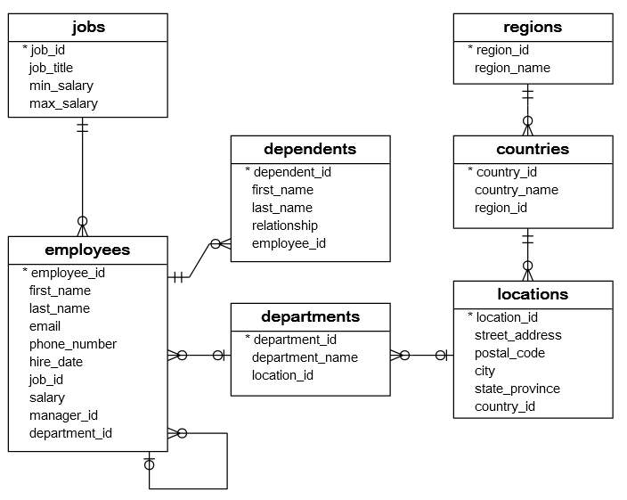

```python
# Inner Join b/w Country and Region tables

country_reg_inner = pd.merge(country, region, how="inner", left_on="region_id", right_on="REGION_ID")
country_reg_inner.head()
```

|  | country_id | country_name | region_id | REGION_ID | REGION_NAME |
| --- | --- | --- | --- | --- | --- |
| 0 | AR | Argentina | 2 | 2 | Americas |
| 1 | AU | Australia | 3 | 3 | Asia |
| 2 | BE | Belgium | 1 | 1 | Europe |
| 3 | BR | Brazil | 2 | 2 | Americas |
| 4 | CA | Canada | 2 | 2 | Americas |

```python
# Joining dept & emp
L1 = pd.merge(dept, emp, how = "left", left_on="manager_id", right_on="employ_id")
L1.head()
```

|  | department_id_x | department_name | manager_id_x | location_id | employ_id | first_name | last_name | email | phone_number | hire_date | job_id | salary | commission_pct | manager_id_y | department_id_y |
| --- | --- | --- | --- | --- | --- | --- | --- | --- | --- | --- | --- | --- | --- | --- | --- |
| 0 | 10 | Administration | 200.0 | 1700 | 200.0 | Jennifer | Whalen | JWHALEN | 515.123.4444 | 9/25/1987 | AD_ASST | 4400.0 | NaN | 101.0 | 10.0 |
| 1 | 20 | Marketing | 201.0 | 1800 | 201.0 | Michael | Hartstein | MHARTSTE | 515.123.5555 | 9/26/1987 | MK_MAN | 13000.0 | NaN | 100.0 | 20.0 |
| 2 | 30 | Purchasing | 114.0 | 1700 | 114.0 | Den | Raphaely | DRAPHEAL | 515.127.4561 | 7/1/1987 | PU_MAN | 11000.0 | NaN | 100.0 | 30.0 |
| 3 | 40 | Human Resources | 203.0 | 2400 | 203.0 | Susan | Mavris | SMAVRIS | 515.123.7777 | 9/28/1987 | HR_REP | 6500.0 | NaN | 101.0 | 40.0 |
| 4 | 50 | Shipping | 121.0 | 1500 | 121.0 | Adam | Fripp | AFRIPP | 650.123.2234 | 7/8/1987 | ST_MAN | 8200.0 | NaN | 100.0 | 50.0 |

```python
# Joining L1 table with Location
L2 = pd.merge(L1, loc, how = "left", on = "location_id")
L2.head()
```

|  | department_id_x | department_name | manager_id_x | location_id | employ_id | first_name | last_name | email | phone_number | hire_date | job_id | salary | commission_pct | manager_id_y | department_id_y | street_address | postal_code | city | state_province | country_id |
| --- | --- | --- | --- | --- | --- | --- | --- | --- | --- | --- | --- | --- | --- | --- | --- | --- | --- | --- | --- | --- |
| 0 | 10 | Administration | 200.0 | 1700 | 200.0 | Jennifer | Whalen | JWHALEN | 515.123.4444 | 9/25/1987 | AD_ASST | 4400.0 | NaN | 101.0 | 10.0 | 2004 Charade Rd | 98199 | Seattle | Washington | US |
| 1 | 20 | Marketing | 201.0 | 1800 | 201.0 | Michael | Hartstein | MHARTSTE | 515.123.5555 | 9/26/1987 | MK_MAN | 13000.0 | NaN | 100.0 | 20.0 | 147 Spadina Ave | M5V 2L7 | Toronto | Ontario | CA |
| 2 | 30 | Purchasing | 114.0 | 1700 | 114.0 | Den | Raphaely | DRAPHEAL | 515.127.4561 | 7/1/1987 | PU_MAN | 11000.0 | NaN | 100.0 | 30.0 | 2004 Charade Rd | 98199 | Seattle | Washington | US |
| 3 | 40 | Human Resources | 203.0 | 2400 | 203.0 | Susan | Mavris | SMAVRIS | 515.123.7777 | 9/28/1987 | HR_REP | 6500.0 | NaN | 101.0 | 40.0 | 8204 Arthur St | NaN | London | NaN | UK |
| 4 | 50 | Shipping | 121.0 | 1500 | 121.0 | Adam | Fripp | AFRIPP | 650.123.2234 | 7/8/1987 | ST_MAN | 8200.0 | NaN | 100.0 | 50.0 | 2011 Interiors Blvd | 99236 | South San Francisco | California | US |

```python
# Join L2 with country
L3 = pd.merge(L2, country, how = "left", on = "country_id")
L3.head()
```

|  | department_id_x | department_name | manager_id_x | location_id | employ_id | first_name | last_name | email | phone_number | hire_date | ... | commission_pct | manager_id_y | department_id_y | street_address | postal_code | city | state_province | country_id | country_name | region_id |
| --- | --- | --- | --- | --- | --- | --- | --- | --- | --- | --- | --- | --- | --- | --- | --- | --- | --- | --- | --- | --- | --- |
| 0 | 10 | Administration | 200.0 | 1700 | 200.0 | Jennifer | Whalen | JWHALEN | 515.123.4444 | 9/25/1987 | ... | NaN | 101.0 | 10.0 | 2004 Charade Rd | 98199 | Seattle | Washington | US | United States of America | 2 |
| 1 | 20 | Marketing | 201.0 | 1800 | 201.0 | Michael | Hartstein | MHARTSTE | 515.123.5555 | 9/26/1987 | ... | NaN | 100.0 | 20.0 | 147 Spadina Ave | M5V 2L7 | Toronto | Ontario | CA | Canada | 2 |
| 2 | 30 | Purchasing | 114.0 | 1700 | 114.0 | Den | Raphaely | DRAPHEAL | 515.127.4561 | 7/1/1987 | ... | NaN | 100.0 | 30.0 | 2004 Charade Rd | 98199 | Seattle | Washington | US | United States of America | 2 |
| 3 | 40 | Human Resources | 203.0 | 2400 | 203.0 | Susan | Mavris | SMAVRIS | 515.123.7777 | 9/28/1987 | ... | NaN | 101.0 | 40.0 | 8204 Arthur St | NaN | London | NaN | UK | United Kingdom | 1 |
| 4 | 50 | Shipping | 121.0 | 1500 | 121.0 | Adam | Fripp | AFRIPP | 650.123.2234 | 7/8/1987 | ... | NaN | 100.0 | 50.0 | 2011 Interiors Blvd | 99236 | South San Francisco | California | US | United States of America | 2 |

5 rows × 22 columns

```python
# Join L3 with region
L4 = pd.merge(L3, region, how="left", left_on="region_id", right_on="REGION_ID")
L4.shape
L4.head()
```

```
(27, 24)
```

|  | department_id_x | department_name | manager_id_x | location_id | employ_id | first_name | last_name | email | phone_number | hire_date | ... | department_id_y | street_address | postal_code | city | state_province | country_id | country_name | region_id | REGION_ID | REGION_NAME |
| --- | --- | --- | --- | --- | --- | --- | --- | --- | --- | --- | --- | --- | --- | --- | --- | --- | --- | --- | --- | --- | --- |
| 0 | 10 | Administration | 200.0 | 1700 | 200.0 | Jennifer | Whalen | JWHALEN | 515.123.4444 | 9/25/1987 | ... | 10.0 | 2004 Charade Rd | 98199 | Seattle | Washington | US | United States of America | 2 | 2 | Americas |
| 1 | 20 | Marketing | 201.0 | 1800 | 201.0 | Michael | Hartstein | MHARTSTE | 515.123.5555 | 9/26/1987 | ... | 20.0 | 147 Spadina Ave | M5V 2L7 | Toronto | Ontario | CA | Canada | 2 | 2 | Americas |
| 2 | 30 | Purchasing | 114.0 | 1700 | 114.0 | Den | Raphaely | DRAPHEAL | 515.127.4561 | 7/1/1987 | ... | 30.0 | 2004 Charade Rd | 98199 | Seattle | Washington | US | United States of America | 2 | 2 | Americas |
| 3 | 40 | Human Resources | 203.0 | 2400 | 203.0 | Susan | Mavris | SMAVRIS | 515.123.7777 | 9/28/1987 | ... | 40.0 | 8204 Arthur St | NaN | London | NaN | UK | United Kingdom | 1 | 1 | Europe |
| 4 | 50 | Shipping | 121.0 | 1500 | 121.0 | Adam | Fripp | AFRIPP | 650.123.2234 | 7/8/1987 | ... | 50.0 | 2011 Interiors Blvd | 99236 | South San Francisco | California | US | United States of America | 2 | 2 | Americas |

5 rows × 24 columns

```python
L4.columns
```

```
Index(['department_id_x', 'department_name', 'manager_id_x', 'location_id',
       'employ_id', 'first_name', 'last_name', 'email', 'phone_number',
       'hire_date', 'job_id', 'salary', 'commission_pct', 'manager_id_y',
       'department_id_y', 'street_address', 'postal_code', 'city',
       'state_province', 'country_id', 'country_name', 'region_id',
       'REGION_ID', 'REGION_NAME'],
      dtype='object')
```

```python
# Drop all the id columns or select only non id columns

# Get the list of id columns
id_cols = [i for i in L4.columns if "id" in i.lower()]
L4.drop(id_cols, axis=1).head()
```

|  | department_name | first_name | last_name | email | phone_number | hire_date | salary | commission_pct | street_address | postal_code | city | state_province | country_name | REGION_NAME |
| --- | --- | --- | --- | --- | --- | --- | --- | --- | --- | --- | --- | --- | --- | --- |
| 0 | Administration | Jennifer | Whalen | JWHALEN | 515.123.4444 | 9/25/1987 | 4400.0 | NaN | 2004 Charade Rd | 98199 | Seattle | Washington | United States of America | Americas |
| 1 | Marketing | Michael | Hartstein | MHARTSTE | 515.123.5555 | 9/26/1987 | 13000.0 | NaN | 147 Spadina Ave | M5V 2L7 | Toronto | Ontario | Canada | Americas |
| 2 | Purchasing | Den | Raphaely | DRAPHEAL | 515.127.4561 | 7/1/1987 | 11000.0 | NaN | 2004 Charade Rd | 98199 | Seattle | Washington | United States of America | Americas |
| 3 | Human Resources | Susan | Mavris | SMAVRIS | 515.123.7777 | 9/28/1987 | 6500.0 | NaN | 8204 Arthur St | NaN | London | NaN | United Kingdom | Europe |
| 4 | Shipping | Adam | Fripp | AFRIPP | 650.123.2234 | 7/8/1987 | 8200.0 | NaN | 2011 Interiors Blvd | 99236 | South San Francisco | California | United States of America | Americas |

```python
# select only non id columns
non_id_cols = [i for i in L4.columns if "id" not in i.lower()]
print(non_id_cols)
L4[non_id_cols].head()
```

```
['department_name', 'first_name', 'last_name', 'email', 'phone_number', 'hire_date', 'salary', 'commission_pct', 'street_address', 'postal_code', 'city', 'state_province', 'country_name', 'REGION_NAME']
```

|  | department_name | first_name | last_name | email | phone_number | hire_date | salary | commission_pct | street_address | postal_code | city | state_province | country_name | REGION_NAME |
| --- | --- | --- | --- | --- | --- | --- | --- | --- | --- | --- | --- | --- | --- | --- |
| 0 | Administration | Jennifer | Whalen | JWHALEN | 515.123.4444 | 9/25/1987 | 4400.0 | NaN | 2004 Charade Rd | 98199 | Seattle | Washington | United States of America | Americas |
| 1 | Marketing | Michael | Hartstein | MHARTSTE | 515.123.5555 | 9/26/1987 | 13000.0 | NaN | 147 Spadina Ave | M5V 2L7 | Toronto | Ontario | Canada | Americas |
| 2 | Purchasing | Den | Raphaely | DRAPHEAL | 515.127.4561 | 7/1/1987 | 11000.0 | NaN | 2004 Charade Rd | 98199 | Seattle | Washington | United States of America | Americas |
| 3 | Human Resources | Susan | Mavris | SMAVRIS | 515.123.7777 | 9/28/1987 | 6500.0 | NaN | 8204 Arthur St | NaN | London | NaN | United Kingdom | Europe |
| 4 | Shipping | Adam | Fripp | AFRIPP | 650.123.2234 | 7/8/1987 | 8200.0 | NaN | 2011 Interiors Blvd | 99236 | South San Francisco | California | United States of America | Americas |

### 5. CROSS JOIN

- Represents the Cartesian product of the two sets (A × B)
- Creates all possible combinations of elements from both tables
- If A has m rows and B has n rows, the result will have m × n rows

```python
region.shape
jobs.shape
region.shape[0]*jobs.shape[0]
pd.merge(region, jobs, how="cross").shape
pd.merge(region, jobs, how="cross").head(50)
```

```
(4, 2)
```

```
(19, 4)
```

```
76
```

```
(76, 6)
```

|  | REGION_ID | REGION_NAME | job_id | job_title | min_salary | max_salary |
| --- | --- | --- | --- | --- | --- | --- |
| 0 | 1 | Europe | AD_PRES | President | 20000 | 40000 |
| 1 | 1 | Europe | AD_VP | Administration Vice President | 15000 | 30000 |
| 2 | 1 | Europe | AD_ASST | Administration Assistant | 3000 | 6000 |
| 3 | 1 | Europe | FI_MGR | Finance Manager | 8200 | 16000 |
| 4 | 1 | Europe | FI_ACCOUNT | Accountant | 4200 | 9000 |
| 5 | 1 | Europe | AC_MGR | Accounting Manager | 8200 | 16000 |
| 6 | 1 | Europe | AC_ACCOUNT | Public Accountant | 4200 | 9000 |
| 7 | 1 | Europe | SA_MAN | Sales Manager | 10000 | 20000 |
| 8 | 1 | Europe | SA_REP | Sales Representative | 6000 | 12000 |
| 9 | 1 | Europe | PU_MAN | Purchasing Manager | 8000 | 15000 |
| 10 | 1 | Europe | PU_CLERK | Purchasing Clerk | 2500 | 5500 |
| 11 | 1 | Europe | ST_MAN | Stock Manager | 5500 | 8500 |
| 12 | 1 | Europe | ST_CLERK | Stock Clerk | 2000 | 5000 |
| 13 | 1 | Europe | SH_CLERK | Shipping Clerk | 2500 | 5500 |
| 14 | 1 | Europe | IT_PROG | Programmer | 4000 | 10000 |
| 15 | 1 | Europe | MK_MAN | Marketing Manager | 9000 | 15000 |
| 16 | 1 | Europe | MK_REP | Marketing Representative | 4000 | 9000 |
| 17 | 1 | Europe | HR_REP | Human Resources Representative | 4000 | 9000 |
| 18 | 1 | Europe | PR_REP | Public Relations Representative | 4500 | 10500 |
| 19 | 2 | Americas | AD_PRES | President | 20000 | 40000 |
| 20 | 2 | Americas | AD_VP | Administration Vice President | 15000 | 30000 |
| 21 | 2 | Americas | AD_ASST | Administration Assistant | 3000 | 6000 |
| 22 | 2 | Americas | FI_MGR | Finance Manager | 8200 | 16000 |
| 23 | 2 | Americas | FI_ACCOUNT | Accountant | 4200 | 9000 |
| 24 | 2 | Americas | AC_MGR | Accounting Manager | 8200 | 16000 |
| 25 | 2 | Americas | AC_ACCOUNT | Public Accountant | 4200 | 9000 |
| 26 | 2 | Americas | SA_MAN | Sales Manager | 10000 | 20000 |
| 27 | 2 | Americas | SA_REP | Sales Representative | 6000 | 12000 |
| 28 | 2 | Americas | PU_MAN | Purchasing Manager | 8000 | 15000 |
| 29 | 2 | Americas | PU_CLERK | Purchasing Clerk | 2500 | 5500 |
| 30 | 2 | Americas | ST_MAN | Stock Manager | 5500 | 8500 |
| 31 | 2 | Americas | ST_CLERK | Stock Clerk | 2000 | 5000 |
| 32 | 2 | Americas | SH_CLERK | Shipping Clerk | 2500 | 5500 |
| 33 | 2 | Americas | IT_PROG | Programmer | 4000 | 10000 |
| 34 | 2 | Americas | MK_MAN | Marketing Manager | 9000 | 15000 |
| 35 | 2 | Americas | MK_REP | Marketing Representative | 4000 | 9000 |
| 36 | 2 | Americas | HR_REP | Human Resources Representative | 4000 | 9000 |
| 37 | 2 | Americas | PR_REP | Public Relations Representative | 4500 | 10500 |
| 38 | 3 | Asia | AD_PRES | President | 20000 | 40000 |
| 39 | 3 | Asia | AD_VP | Administration Vice President | 15000 | 30000 |
| 40 | 3 | Asia | AD_ASST | Administration Assistant | 3000 | 6000 |
| 41 | 3 | Asia | FI_MGR | Finance Manager | 8200 | 16000 |
| 42 | 3 | Asia | FI_ACCOUNT | Accountant | 4200 | 9000 |
| 43 | 3 | Asia | AC_MGR | Accounting Manager | 8200 | 16000 |
| 44 | 3 | Asia | AC_ACCOUNT | Public Accountant | 4200 | 9000 |
| 45 | 3 | Asia | SA_MAN | Sales Manager | 10000 | 20000 |
| 46 | 3 | Asia | SA_REP | Sales Representative | 6000 | 12000 |
| 47 | 3 | Asia | PU_MAN | Purchasing Manager | 8000 | 15000 |
| 48 | 3 | Asia | PU_CLERK | Purchasing Clerk | 2500 | 5500 |
| 49 | 3 | Asia | ST_MAN | Stock Manager | 5500 | 8500 |

## Handling DateTime in Pandas

### Dataset URL: `https://gogl.to/3gXD`

```python
log_df = pd.read_csv(r"D:\Datasets\Server_log_file.txt")
```

```python
log_df.head()
```

|  | datetime | server_id | cpu_utilization | free_memory | session_count |
| --- | --- | --- | --- | --- | --- |
| 0 | 2019-03-06 00:00:00 | 100 | 0.40 | 0.54 | 52 |
| 1 | 2019-03-06 01:00:00 | 100 | 0.49 | 0.51 | 58 |
| 2 | 2019-03-06 02:00:00 | 100 | 0.49 | 0.54 | 53 |
| 3 | 2019-03-06 03:00:00 | 100 | 0.44 | 0.56 | 49 |
| 4 | 2019-03-06 04:00:00 | 100 | 0.42 | 0.52 | 54 |

```python
log_df.info()
```

```
<class 'pandas.core.frame.DataFrame'>
RangeIndex: 40800 entries, 0 to 40799
Data columns (total 5 columns):
 #   Column           Non-Null Count  Dtype
---  ------           --------------  -----
 0   datetime         40800 non-null  object
 1   server_id        40800 non-null  int64
 2   cpu_utilization  40800 non-null  float64
 3   free_memory      40800 non-null  float64
 4   session_count    40800 non-null  int64
dtypes: float64(2), int64(2), object(1)
memory usage: 1.6+ MB
```

```python
# convert the object column to datetome in pandas
log_df['datetime'].head()

pd.to_datetime(log_df['datetime'])

# Apply the changes by overwrting the column in the DF
log_df['datetime'] = pd.to_datetime(log_df['datetime'])
```

```
0    2019-03-06 00:00:00
1    2019-03-06 01:00:00
2    2019-03-06 02:00:00
3    2019-03-06 03:00:00
4    2019-03-06 04:00:00
Name: datetime, dtype: object
```

```
0       2019-03-06 00:00:00
1       2019-03-06 01:00:00
2       2019-03-06 02:00:00
3       2019-03-06 03:00:00
4       2019-03-06 04:00:00
                ...
40795   2019-04-08 19:00:00
40796   2019-04-08 20:00:00
40797   2019-04-08 21:00:00
40798   2019-04-08 22:00:00
40799   2019-04-08 23:00:00
Name: datetime, Length: 40800, dtype: datetime64[ns]
```

```python
log_df.info()
```

```
<class 'pandas.core.frame.DataFrame'>
RangeIndex: 40800 entries, 0 to 40799
Data columns (total 5 columns):
 #   Column           Non-Null Count  Dtype
---  ------           --------------  -----
 0   datetime         40800 non-null  datetime64[ns]
 1   server_id        40800 non-null  int64
 2   cpu_utilization  40800 non-null  float64
 3   free_memory      40800 non-null  float64
 4   session_count    40800 non-null  int64
dtypes: datetime64[ns](1), float64(2), int64(2)
memory usage: 1.6 MB
```

```python
# Find the max and min timestamp in the datetime column
log_df['datetime'].min()
log_df['datetime'].max()

log_df['datetime'].max()-log_df['datetime'].min()

type(log_df['datetime'].max())
```

```
Timestamp('2019-03-06 00:00:00')
```

```
Timestamp('2019-04-08 23:00:00')
```

```
Timedelta('33 days 23:00:00')
```

```
pandas._libs.tslibs.timestamps.Timestamp
```